# Acompanhamento das metas dos ODS

# Introdução

## Sobre a classificação dos dados

Para definir se uma variável está próxima ou não de atingir um objetivo, é necessário definir como será calculada cada quebra. Tanto quando há a definição clara de qual valor define um objetivo como atingido, quanto quando o objetivo atingido equivale a completude de um processo (0% ou 100%, a depender do dado utilizado), é necessário apontar onde serão os cortes de valores dentre os municípios que não fazem parte do grupo que cumpriu a meta. Portanto, para dizer se um município está mais próximo ou mais distante de uma meta, intervalos de valores que definam o que é próximo e o que é distante precisam ser atribuídos.

Dado a escolha da classificação, é necessário definir quantas e quais serão as classes. No caso da meta possuir um valor claro para definir se ela foi atingida (por ex.: menos de 3%, menos de 5 por mil nascidos vivos), a primeira categoria consiste nos municípios dentro dessa meta e, as demais categorias, consistem na separação dos dados em quatro categorias, classificadas pelo método de quebras naturais. No caso da meta não apresentar um valor objetivo definido para o seu cumprimento, houveram duas possibilidades: quando os valores estão relacionados a uma escala conhecida (como porcentagem), os municípios que apresentaram valores de atendimento perfeito à meta foram classificados como municipios que atingiram aquela meta (por exemplo, municípios com 100% de abastecimento de água).

Portanto, as classificações apresentam as seguintes categorias: + Municípios que atingiram a meta + Municípios muito próximos de atingir a meta + Municípios próximos de atingir a meta + Municípios distantes de atingir a meta + Municípios muito distantes de atingir a meta

## Ano dos dados

Foram considerados, para todos os indicadores disponibilizados, o ano mais recente presente nas tabelas de dados, sendo este normalmente 2016, 2017 ou 2018. O ano utilizado está indicado na descrição de cada ODS.

## Sobre a estrutura do documento

Quando a meta definida inicialmente pela ONU teve seus valores redesenhados pelo IBGE/IPEA para melhor se adaptar à realidade do país, o documento se subdivide em duas categorias, uma tratando da meta original da ONU e, outra, tratando da meta brasileira.

# ODS 1 - Erradicação da pobreza

**ODS 1: Acabar com a pobreza em todas as suas formas, em todos os lugares**

O primeiro ODS, associado à erradicação da pobreza, será analisado a partir da meta 1.1, com indicador que fornece a porcentagem de pessoas vivendo na pobreza extrema no ano de 2017.

- Meta 1.1:
  - **ONU:** Até 2030, erradicar a pobreza extrema para todas as pessoas em todos os lugares, atualmente medida como pessoas vivendo com menos de US$ 1,25 por dia.
  - **IBGE/IPEA:** Até 2030, erradicar a pobreza extrema para todas as pessoas em todos os lugares, medida como pessoas vivendo com menos de PPC$ 3,20 per capita por dia.

O mapa abaixo mostra a distribuição espacial geral dos dados no Brasil:

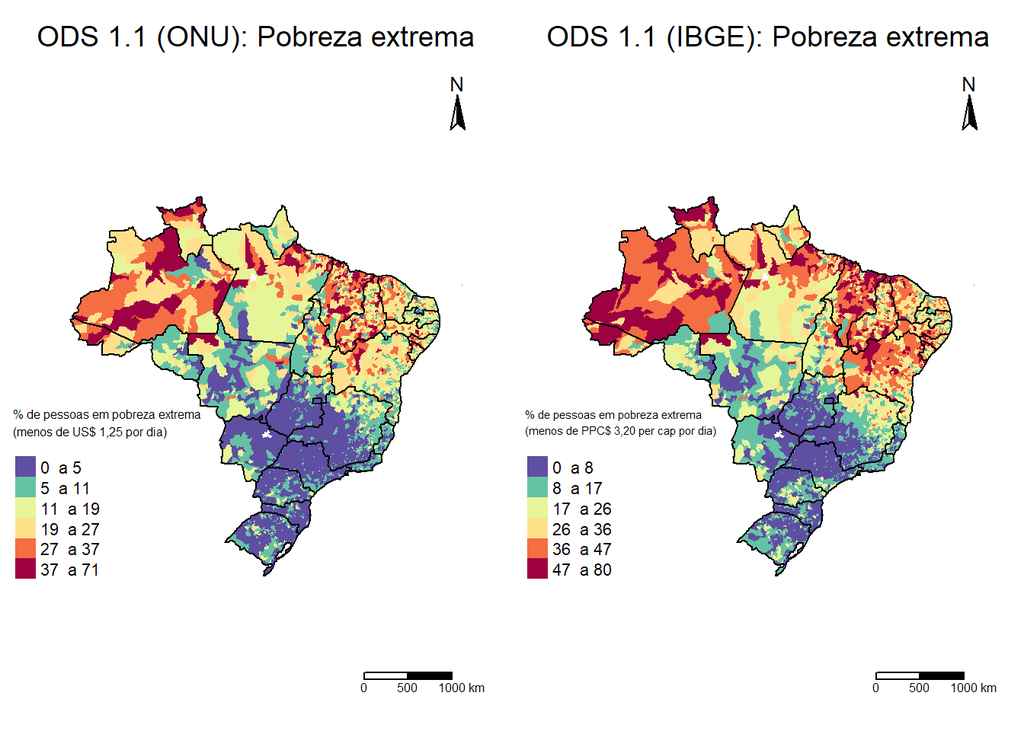

Abaixo, a tabela apresenta as médias de valores por região do Brasil:

| REGIAO | % de pessoas em pobreza extrema (ONU) | % de pessoas em pobreza extrema (IBGE) |
| --- | --- | --- |
| Centro-Oeste | 6.25 | 10.84 |
| Nordeste | 20.61 | 33.87 |
| Norte | 19.63 | 30.90 |
| Sudeste | 4.60 | 9.70 |
| Sul | 3.29 | 6.33 |

## Critérios ONU

**Cortes**

Para determinar as cinco categorias de proximidade do cumprimento do ODS, foi utilizado a classificação de quebras naturais para os grupos que ainda não atingiram a meta da ONU.

- Meta ODS atingida: Até 3% de população em pobreza extrema.
- Meta ODS muito próxima de ser atingida: De 3% a 10.41%.
- Meta ODS próxima de ser atingida: De 10.41% a 19.87%.
- Meta ODS distante de ser atingida: De 19.87% a 31.54%.
- Meta ODS muito distante de ser atingida: De 31.54% a 71.16%.

**Resumo por região**

ODS Meta 1.1 (ONU) - Pobreza extrema (2017)

| REGIAO | Meta ODS atingida | Municípios próximos de atingir a meta ODS Meta ODS muito próxima de ser atingida | Municípios próximos de atingir a meta ODS Meta ODS próxima de ser atingida | Municípios distantes de atingir a meta ODS Meta ODS distante de ser atingida | Municípios distantes de atingir a meta ODS Meta ODS muito distante de ser atingida |
| --- | --- | --- | --- | --- | --- |
| Centro-Oeste | 38,0% | 44,8% | 13,1% | 3,4% | 0,6% |
| Nordeste | 0,45% | 13,16% | 38,09% | 34,63% | 13,66% |
| Norte | 1,78% | 24,94% | 28,51% | 28,29% | 16,48% |
| Sudeste | 49,4% | 40,5% | 8,6% | 1,4% | 0,2% |
| Sul | 63,0% | 31,2% | 5,2% | 0,5% | Não há |

**Distribuição espacial**

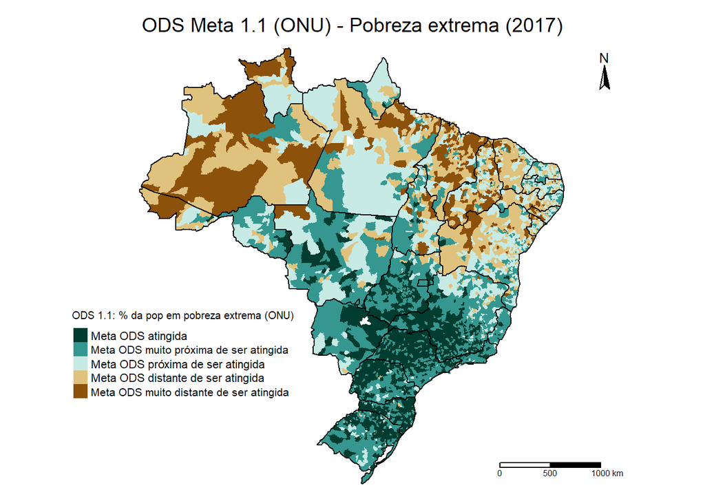

#### Resumo por biomas

ODS Meta 1.1 - Critérios ONU

[output not shown]

#### Resumo por tipologias

ODS Meta 1.1 - Critérios ONU

| Tipologia | Nº total de municípios | Meta ODS atingida Nº de municípios | Meta ODS atingida % no bioma | Municípios próximos de atingir a meta ODS Muito próximos Nº de municípios | Municípios próximos de atingir a meta ODS Muito próximos % no bioma | Municípios próximos de atingir a meta ODS Próximos Nº de municípios | Municípios próximos de atingir a meta ODS Próximos % no bioma | Municípios distantes de atingir a meta ODS Distantes Nº de municípios | Municípios distantes de atingir a meta ODS Distantes % no bioma | Municípios distantes de atingir a meta ODS Muito distantes Nº de municípios | Municípios distantes de atingir a meta ODS Muito distantes % no bioma |
| --- | --- | --- | --- | --- | --- | --- | --- | --- | --- | --- | --- |
| Intermediário | 891 | 303 | 34.0% | 222 | 24.9% | 228 | 25.6% | 113 | 12.7% | 25 | 2.8% |
| Rural | 4363 | 1341 | 30.7% | 1218 | 27.9% | 828 | 19.0% | 676 | 15.5% | 300 | 6.9% |
| Urbano | 310 | 122 | 39.4% | 163 | 52.6% | 21 | 6.8% | 4 | 1.3% | Não há | Não há |

## Critérios IBGE

**Cortes**

Para determinar as cinco categorias de proximidade do cumprimento do ODS, foi utilizado a classificação de quebras naturais para os grupos que ainda não atingiram a meta da IBGE.

- Meta ODS atingida: Até 3% de população em pobreza extrema.
- Meta ODS muito próxima de ser atingida: De 3.01% a 13.31%.
- Meta ODS próxima de ser atingida: De 13.31% a 26.53%.
- Meta ODS distante de ser atingida: De 26.53% a 40.98%.
- Meta ODS muito distante de ser atingida: De 40.98% a 80.33%.

**Resumo por região**

ODS Meta 1.1 (IBGE) - Pobreza extrema (2017)

| REGIAO | Meta ODS atingida | Municípios próximos de atingir a meta ODS Meta ODS muito próxima de ser atingida | Municípios próximos de atingir a meta ODS Meta ODS próxima de ser atingida | Municípios distantes de atingir a meta ODS Meta ODS distante de ser atingida | Municípios distantes de atingir a meta ODS Meta ODS muito distante de ser atingida |
| --- | --- | --- | --- | --- | --- |
| Centro-Oeste | 7,3% | 64,4% | 23,0% | 4,1% | 1,3% |
| Nordeste | Não há | 3,1% | 23,9% | 46,8% | 26,2% |
| Norte | Não há | 9,13% | 32,74% | 32,96% | 25,17% |
| Sudeste | 17,8% | 57,4% | 19,4% | 4,7% | 0,6% |
| Sul | 34,8% | 53,9% | 10,4% | 0,9% | Não há |

**Distribuição espacial**

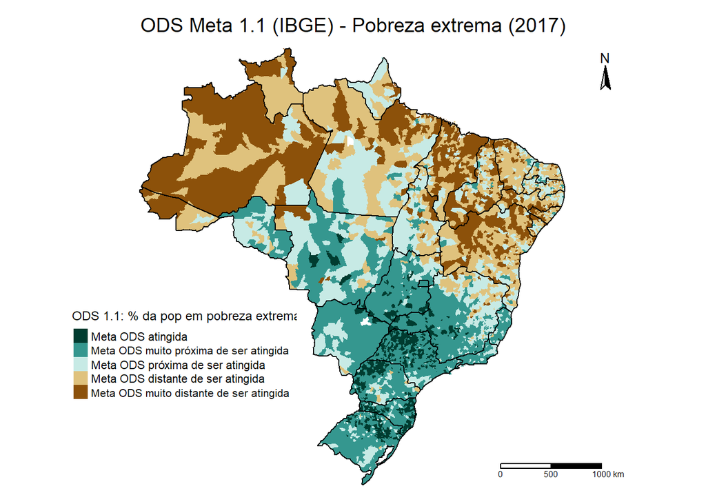

#### Resumo por biomas

ODS Meta 1.1 - Critérios IBGE

| Bioma | Nº total de municípios | Meta ODS atingida Nº de municípios | Meta ODS atingida % no bioma | Municípios próximos de atingir a meta ODS Muito próximos Nº de municípios | Municípios próximos de atingir a meta ODS Muito próximos % no bioma | Municípios próximos de atingir a meta ODS Próximos Nº de municípios | Municípios próximos de atingir a meta ODS Próximos % no bioma | Municípios distantes de atingir a meta ODS Distantes Nº de municípios | Municípios distantes de atingir a meta ODS Distantes % no bioma | Municípios distantes de atingir a meta ODS Muito distantes Nº de municípios | Municípios distantes de atingir a meta ODS Muito distantes % no bioma |
| --- | --- | --- | --- | --- | --- | --- | --- | --- | --- | --- | --- |
| Amazonia | 553 | 3 | 0.5% | 80 | 14.5% | 136 | 24.6% | 164 | 29.7% | 170 | 30.7% |
| Caatinga | 1217 | Não há | Não há | 36 | 3.0% | 300 | 24.7% | 594 | 48.8% | 287 | 23.6% |
| Cerrado | 806 | 78 | 9.7% | 367 | 45.5% | 163 | 20.2% | 105 | 13.0% | 93 | 11.5% |
| Mata Atlântica | 2875 | 662 | 23.0% | 1427 | 49.6% | 504 | 17.5% | 233 | 8.1% | 49 | 1.7% |
| Pampa | 94 | 2 | 2.1% | 72 | 76.6% | 19 | 20.2% | 1 | 1.1% | Não há | Não há |
| Pantanal | 19 | Não há | Não há | 12 | 63.2% | 7 | 36.8% | Não há | Não há | Não há | Não há |

#### Resumo por tipologias

ODS Meta 1.1 - Critérios IBGE

| Tipologia | Nº total de municípios | Meta ODS atingida Nº de municípios | Meta ODS atingida % no bioma | Municípios próximos de atingir a meta ODS Muito próximos Nº de municípios | Municípios próximos de atingir a meta ODS Muito próximos % no bioma | Municípios próximos de atingir a meta ODS Próximos Nº de municípios | Municípios próximos de atingir a meta ODS Próximos % no bioma | Municípios distantes de atingir a meta ODS Distantes Nº de municípios | Municípios distantes de atingir a meta ODS Distantes % no bioma | Municípios distantes de atingir a meta ODS Muito distantes Nº de municípios | Municípios distantes de atingir a meta ODS Muito distantes % no bioma |
| --- | --- | --- | --- | --- | --- | --- | --- | --- | --- | --- | --- |
| Intermediário | 891 | 141 | 15.8% | 314 | 35.2% | 150 | 16.8% | 233 | 26.2% | 53 | 5.9% |
| Rural | 4363 | 558 | 12.8% | 1482 | 34.0% | 923 | 21.2% | 854 | 19.6% | 546 | 12.5% |
| Urbano | 310 | 46 | 14.8% | 198 | 63.9% | 56 | 18.1% | 10 | 3.2% | Não há | Não há |

# ODS 2 - Fome zero e agricultura sustentável

**ODS 2: Acabar com a fome, alcançar a segurança alimentar e melhoria da nutrição e promover a agricultura sustentável**

O segundo ODS, associado à alimentação e agricultura, será analisado utilizando a meta 2.1, que trata da tentativa de erradicar a fome. Por ausência de indicador definido pelo IBGE, será utilizado o indicador de prevalência de subalimentação em crianças de 0 a 2 anos no ano de 2015, sendo os municípios com valores zerados considerados como aqueles que atingiram a meta.

- Meta 2.1
  - **ONU**: Até 2030, acabar com a fome e garantir o acesso de todas as pessoas, em particular os pobres e pessoas em situações vulneráveis, incluindo crianças, a alimentos seguros, nutritivos e suficientes durante todo o ano.
  - **IBGE/IPEA**: Até 2030, erradicar a fome e garantir o acesso de todas as pessoas, em particular os pobres e pessoas em situações vulneráveis, incluindo crianças e idosos, a alimentos seguros, culturalmente adequados, saudáveis e suficientes durante todo o ano.

O mapa abaixo mostra a distribuição espacial geral dos dados no Brasil:

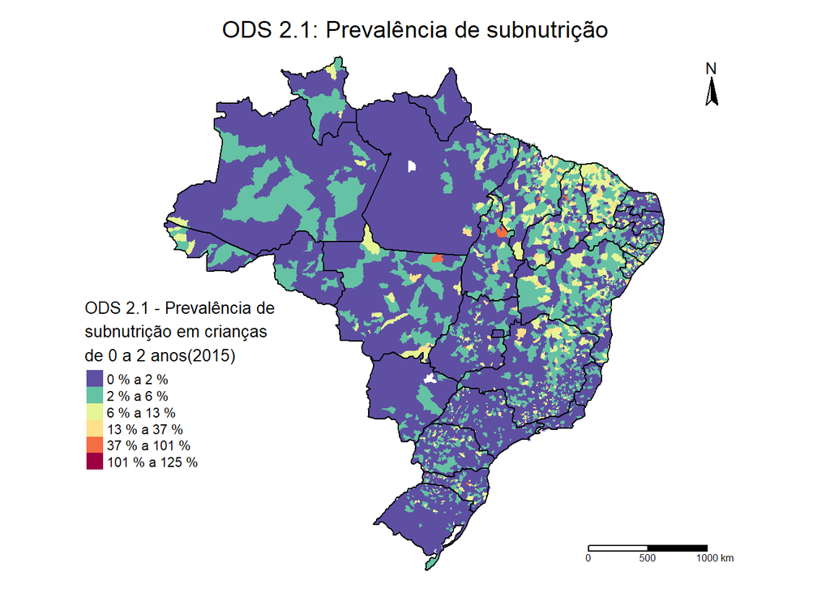

Abaixo, a tabela apresenta as médias de valores por região do Brasil em 2015:

ODS Meta 2.1 - Prevalência de subnutrição em crianças de 0 a 2 anos

| REGIAO | Média da prevalência de subnutrição |
| --- | --- |
| Centro-Oeste | 2.00% |
| Nordeste | 4.15% |
| Norte | 2.30% |
| Sudeste | 2.00% |
| Sul | 1.44% |

## Critérios únicos (ONU e IBGE/IPEA)

**Cortes**

Para determinar as cinco categorias de proximidade do cumprimento do ODS, foi utilizado a classificação de quebras naturais para os grupos que ainda não atingiram a meta da ONU.

- Meta ODS atingida: 0% de crianças subnutridas.
- Meta ODS muito próxima de ser atingida: De 0.01% a 4.09%.
- Meta ODS próxima de ser atingida: De 4.09% a 11.36%.
- Meta ODS distante de ser atingida: De 11.36% a 33.33%.
- Meta ODS muito distante de ser atingida: De 33.33% a 125.39%.

**Resumo por região**

ODS Meta 2.1 - Prevalência de subnutrição em crianças de 0 a 2 anos (2015)

| REGIAO | Meta ODS atingida | Municípios próximos de atingir a meta ODS Meta ODS muito próxima de ser atingida | Municípios próximos de atingir a meta ODS Meta ODS próxima de ser atingida | Municípios distantes de atingir a meta ODS Meta ODS distante de ser atingida | Municípios distantes de atingir a meta ODS Meta ODS muito distante de ser atingida |
| --- | --- | --- | --- | --- | --- |
| Centro-Oeste | 35,2% | 52,1% | 10,3% | 1,9% | 0,4% |
| Nordeste | 20,5% | 42,7% | 29,4% | 7,0% | 0,3% |
| Norte | 24,5% | 57,5% | 14,7% | 3,1% | 0,2% |
| Sudeste | 36,3% | 49,0% | 11,6% | 3,0% | 0,1% |
| Sul | 52,7% | 37,0% | 8,5% | 1,7% | 0,1% |

**Distribuição espacial**

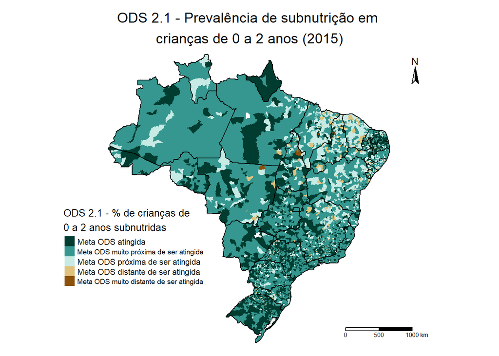

#### Resumo por biomas

ODS Meta 2.1 - Prevalência de subnutrição em crianças de 0 a 2 anos (2015)

| Bioma | Nº total de municípios | Meta ODS atingida Nº de municípios | Meta ODS atingida % no bioma | Municípios próximos de atingir a meta ODS Muito próximos Nº de municípios | Municípios próximos de atingir a meta ODS Muito próximos % no bioma | Municípios próximos de atingir a meta ODS Próximos Nº de municípios | Municípios próximos de atingir a meta ODS Próximos % no bioma | Municípios distantes de atingir a meta ODS Distantes Nº de municípios | Municípios distantes de atingir a meta ODS Distantes % no bioma | Municípios distantes de atingir a meta ODS Muito distantes Nº de municípios | Municípios distantes de atingir a meta ODS Muito distantes % no bioma |
| --- | --- | --- | --- | --- | --- | --- | --- | --- | --- | --- | --- |
| Amazonia | 553 | 105 | 19.0% | 340 | 61.5% | 91 | 16.5% | 15 | 2.7% | 2 | 0.4% |
| Caatinga | 1217 | 288 | 23.7% | 464 | 38.1% | 368 | 30.2% | 93 | 7.6% | 4 | 0.3% |
| Cerrado | 806 | 256 | 31.8% | 371 | 46.0% | 137 | 17.0% | 38 | 4.7% | 4 | 0.5% |
| Mata Atlântica | 2875 | 1158 | 40.3% | 1304 | 45.4% | 339 | 11.8% | 73 | 2.5% | 1 | 0.0% |
| Pampa | 94 | 60 | 63.8% | 33 | 35.1% | 1 | 1.1% | Não há | Não há | Não há | Não há |
| Pantanal | 19 | 5 | 26.3% | 13 | 68.4% | 1 | 5.3% | Não há | Não há | Não há | Não há |

#### Resumo por tipologias

ODS Meta 2.1 - Prevalência de subnutrição em crianças de 0 a 2 anos (2015)

| Tipologia | Nº total de municípios | Meta ODS atingida Nº de municípios | Meta ODS atingida % no bioma | Municípios próximos de atingir a meta ODS Muito próximos Nº de municípios | Municípios próximos de atingir a meta ODS Muito próximos % no bioma | Municípios próximos de atingir a meta ODS Próximos Nº de municípios | Municípios próximos de atingir a meta ODS Próximos % no bioma | Municípios distantes de atingir a meta ODS Distantes Nº de municípios | Municípios distantes de atingir a meta ODS Distantes % no bioma | Municípios distantes de atingir a meta ODS Muito distantes Nº de municípios | Municípios distantes de atingir a meta ODS Muito distantes % no bioma |
| --- | --- | --- | --- | --- | --- | --- | --- | --- | --- | --- | --- |
| Intermediário | 891 | 235 | 26.4% | 510 | 57.2% | 130 | 14.6% | 16 | 1.8% | Não há | Não há |
| Rural | 4363 | 1572 | 36.0% | 1782 | 40.8% | 795 | 18.2% | 203 | 4.7% | 11 | 0.3% |
| Urbano | 310 | 65 | 21.0% | 233 | 75.2% | 12 | 3.9% | Não há | Não há | Não há | Não há |

# ODS 3 - Saúde e bem-estar

**ODS 3: Assegurar uma vida saudável e promover o bem-estar para todos, em todas as idades**

O terceiro ODS, associado à saúde e bem-estar, será analisado utilizando a meta 3.2, que trata da mortalidade neonatal e infantil, com dados do ano de 2017.

- Meta 3.2:
  - **ONU:** Até 2030, acabar com as mortes evitáveis de recém-nascidos e crianças menores de 5 anos, com todos os países objetivando reduzir a mortalidade neonatal para pelo menos 12 por 1.000 nascidos vivos e a mortalidade de crianças menores de 5 anos para pelo menos 25 por 1.000 nascidos vivos.
  - **IBGE/IPEA** Até 2030, enfrentar as mortes evitáveis de recém-nascidos e crianças menores de 5 anos, objetivando reduzir a mortalidade neonatal para no máximo 5 por mil nascidos vivos e a mortalidade de crianças menores de 5 anos para no máximo 8 por mil nascidos vivos.

O mapa abaixo mostra a distribuição espacial geral dos dados no Brasil:

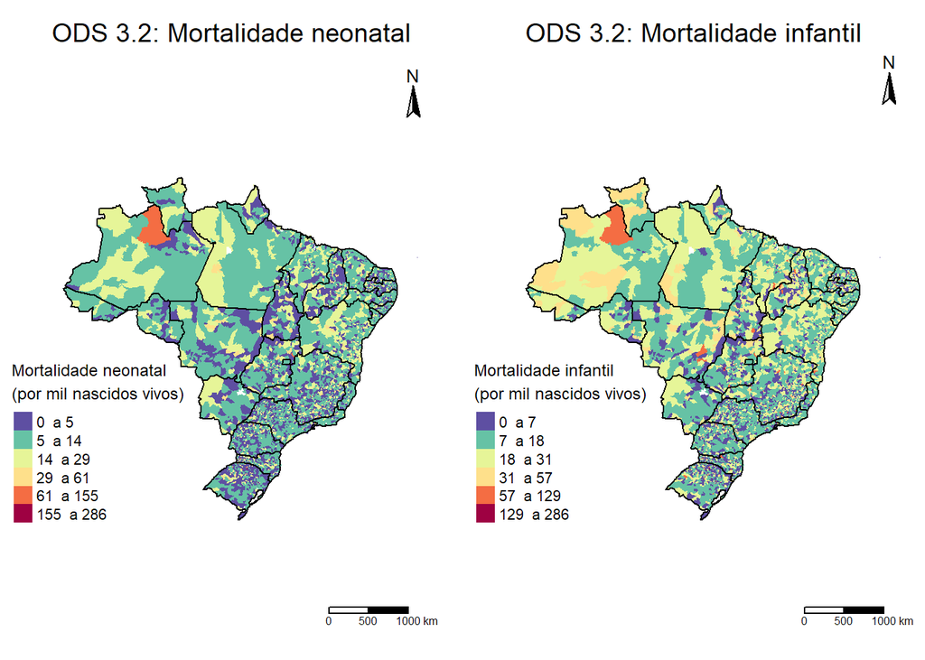

Abaixo, a tabela apresenta as médias de valores por região do Brasil para a mortalidade neonatal e infantil em 2017:

ODS Meta 3.2 - Mortalidade infantil e neonatal (2017)*

| REGIAO | Tx. de mortalidade neonatal | Tx. de mortalidade infantil |
| --- | --- | --- |
| Centro-Oeste | 9.11 | 15.23 |
| Nordeste | 10.23 | 16.87 |
| Norte | 9.58 | 17.72 |
| Sudeste | 8.71 | 14.31 |
| Sul | 7.91 | 12.63 |

<sup>a</sup> *Taxa de Mortalidade neonatal considerada para crianças de até 28 dias (por mil nascidos vivos) e mortalidade infantil para crianças de 0 a 4 anos de idade (por mil nascidos vivos).

## Critérios ONU

### Neonatal

**Cortes**

Para determinar as cinco categorias de proximidade do cumprimento do ODS, foi utilizado a classificação de quebras naturais para os grupos que ainda não atingiram a meta da ONU.

- Meta ODS atingida: De 0 a 12 por mil nascidos vivos.
- Meta ODS muito próxima de ser atingida: De 12 a 27.09 por mil nascidos vivos.
- Meta ODS próxima de ser atingida: De 27.09 a 58.82 por mil nascidos vivos.
- Meta ODS distante de ser atingida: De 58.82 a 142.86 por mil nascidos vivos.
- Meta ODS muito distante de ser atingida: De 142.86 a 285.71 por mil nascidos vivos.

**Resumo por região**

ODS Meta 3.2 (ONU) - Mortalidade neonatal (2017)

| REGIAO | Meta ODS atingida | Municípios próximos de atingir a meta ODS Meta ODS muito próxima de ser atingida | Municípios próximos de atingir a meta ODS Meta ODS próxima de ser atingida | Municípios distantes de atingir a meta ODS Meta ODS distante de ser atingida | Municípios distantes de atingir a meta ODS Meta ODS muito distante de ser atingida |
| --- | --- | --- | --- | --- | --- |
| Centro-Oeste | 74,7% | 18,7% | 6,0% | 0,6% | Não há |
| Nordeste | 64,4% | 31,3% | 4,2% | 0,1% | Não há |
| Norte | 66,4% | 30,3% | 3,1% | 0,2% | Não há |
| Sudeste | 75,60% | 18,82% | 5,16% | 0,36% | 0,06% |
| Sul | 79,29% | 14,73% | 4,88% | 0,93% | 0,17% |

**Distribuição espacial**

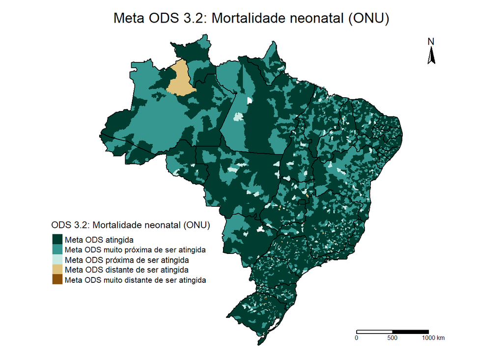

#### Resumo por biomas

ODS Meta 3.2 [Mortalidade neonatal] - Critérios ONU

| Bioma | Nº total de municípios | Meta ODS atingida Nº de municípios | Meta ODS atingida % no bioma | Municípios próximos de atingir a meta ODS Muito próximos Nº de municípios | Municípios próximos de atingir a meta ODS Muito próximos % no bioma | Municípios próximos de atingir a meta ODS Próximos Nº de municípios | Municípios próximos de atingir a meta ODS Próximos % no bioma | Municípios distantes de atingir a meta ODS Distantes Nº de municípios | Municípios distantes de atingir a meta ODS Distantes % no bioma | Municípios distantes de atingir a meta ODS Muito distantes Nº de municípios | Municípios distantes de atingir a meta ODS Muito distantes % no bioma |
| --- | --- | --- | --- | --- | --- | --- | --- | --- | --- | --- | --- |
| Amazonia | 553 | 371 | 67.1% | 170 | 30.7% | 11 | 2.0% | 1 | 0.2% | Não há | Não há |
| Caatinga | 1217 | 791 | 65.0% | 372 | 30.6% | 53 | 4.4% | 1 | 0.1% | Não há | Não há |
| Cerrado | 806 | 576 | 71.5% | 175 | 21.7% | 52 | 6.5% | 3 | 0.4% | Não há | Não há |
| Mata Atlântica | 2875 | 2178 | 75.8% | 537 | 18.7% | 140 | 4.9% | 17 | 0.6% | 3 | 0.1% |
| Pampa | 94 | 76 | 80.9% | 13 | 13.8% | 5 | 5.3% | Não há | Não há | Não há | Não há |
| Pantanal | 19 | 12 | 63.2% | 6 | 31.6% | 1 | 5.3% | Não há | Não há | Não há | Não há |

#### Resumo por tipologias

ODS Meta 3.2 [mortalidade neonatal] - Critérios ONU

| Tipologia | Nº total de municípios | Meta ODS atingida Nº de municípios | Meta ODS atingida % no bioma | Municípios próximos de atingir a meta ODS Muito próximos Nº de municípios | Municípios próximos de atingir a meta ODS Muito próximos % no bioma | Municípios próximos de atingir a meta ODS Próximos Nº de municípios | Municípios próximos de atingir a meta ODS Próximos % no bioma | Municípios distantes de atingir a meta ODS Distantes Nº de municípios | Municípios distantes de atingir a meta ODS Distantes % no bioma | Municípios distantes de atingir a meta ODS Muito distantes Nº de municípios | Municípios distantes de atingir a meta ODS Muito distantes % no bioma |
| --- | --- | --- | --- | --- | --- | --- | --- | --- | --- | --- | --- |
| Intermediário | 891 | 689 | 77.3% | 192 | 21.5% | 10 | 1.1% | Não há | Não há | Não há | Não há |
| Rural | 4363 | 3034 | 69.5% | 1052 | 24.1% | 252 | 5.8% | 22 | 0.5% | 3 | 0.1% |
| Urbano | 310 | 281 | 90.6% | 29 | 9.4% | Não há | Não há | Não há | Não há | Não há | Não há |

### Infantil

**Cortes**

Para determinar as cinco categorias de proximidade do cumprimento do ODS, foi utilizado a classificação de quebras naturais para os grupos que ainda não atingiram a meta da ONU.

- Meta ODS atingida: De 0 a 25 por mil nascidos vivos.
- Meta ODS muito próxima de ser atingida: De 25.07 a 37.59 por mil nascidos vivos.
- Meta ODS próxima de ser atingida: De 37.59 a 61.22 por mil nascidos vivos.
- Meta ODS distante de ser atingida: De 61.22 a 121.21 por mil nascidos vivos.
- Meta ODS muito distante de ser atingida: De 121.21 a 285.71 por mil nascidos vivos.

**Resumo por região**

ODS Meta 3.2 (ONU) - Mortalidade infantil (2017)*

| REGIAO | Meta ODS atingida | Municípios próximos de atingir a meta ODS Meta ODS muito próxima de ser atingida | Municípios próximos de atingir a meta ODS Meta ODS próxima de ser atingida | Municípios distantes de atingir a meta ODS Meta ODS distante de ser atingida | Municípios distantes de atingir a meta ODS Meta ODS muito distante de ser atingida |
| --- | --- | --- | --- | --- | --- |
| Centro-Oeste | 91,85% | 4,08% | 3,43% | 0,64% | Não há |
| Nordeste | 94,1% | 4,6% | 1,3% | 0,1% | Não há |
| Norte | 95,99% | 3,34% | 0,45% | 0,22% | Não há |
| Sudeste | 93,47% | 3,84% | 2,28% | 0,36% | 0,06% |
| Sul | 93,27% | 3,70% | 1,94% | 0,84% | 0,25% |

**Distribuição espacial**

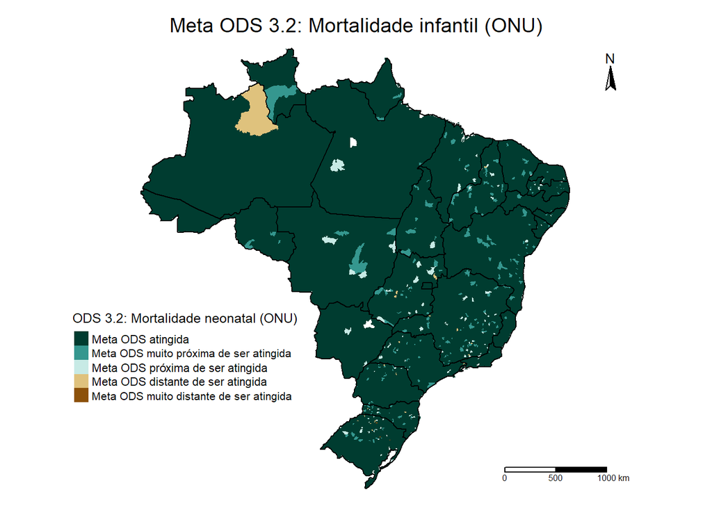

#### Resumo por biomas

ODS Meta 3.2 [Mortalidade infantil] - Critérios ONU

| Bioma | Nº total de municípios | Meta ODS atingida Nº de municípios | Meta ODS atingida % no bioma | Municípios próximos de atingir a meta ODS Muito próximos Nº de municípios | Municípios próximos de atingir a meta ODS Muito próximos % no bioma | Municípios próximos de atingir a meta ODS Próximos Nº de municípios | Municípios próximos de atingir a meta ODS Próximos % no bioma | Municípios distantes de atingir a meta ODS Distantes Nº de municípios | Municípios distantes de atingir a meta ODS Distantes % no bioma | Municípios distantes de atingir a meta ODS Muito distantes Nº de municípios | Municípios distantes de atingir a meta ODS Muito distantes % no bioma |
| --- | --- | --- | --- | --- | --- | --- | --- | --- | --- | --- | --- |
| Amazonia | 553 | 538 | 97.3% | 12 | 2.2% | 2 | 0.4% | 1 | 0.2% | Não há | Não há |
| Caatinga | 1217 | 1145 | 94.1% | 55 | 4.5% | 16 | 1.3% | 1 | 0.1% | Não há | Não há |
| Cerrado | 806 | 739 | 91.7% | 40 | 5.0% | 24 | 3.0% | 3 | 0.4% | Não há | Não há |
| Mata Atlântica | 2875 | 2684 | 93.4% | 115 | 4.0% | 56 | 1.9% | 16 | 0.6% | 4 | 0.1% |
| Pampa | 94 | 89 | 94.7% | 2 | 2.1% | 3 | 3.2% | Não há | Não há | Não há | Não há |
| Pantanal | 19 | 18 | 94.7% | Não há | Não há | 1 | 5.3% | Não há | Não há | Não há | Não há |

#### Resumo por tipologias

ODS Meta 3.2 [mortalidade infantil] - Critérios ONU

| Tipologia | Nº total de municípios | Meta ODS atingida Nº de municípios | Meta ODS atingida % no bioma | Municípios próximos de atingir a meta ODS Muito próximos Nº de municípios | Municípios próximos de atingir a meta ODS Muito próximos % no bioma | Municípios próximos de atingir a meta ODS Próximos Nº de municípios | Municípios próximos de atingir a meta ODS Próximos % no bioma | Municípios distantes de atingir a meta ODS Distantes Nº de municípios | Municípios distantes de atingir a meta ODS Distantes % no bioma | Municípios distantes de atingir a meta ODS Muito distantes Nº de municípios | Municípios distantes de atingir a meta ODS Muito distantes % no bioma |
| --- | --- | --- | --- | --- | --- | --- | --- | --- | --- | --- | --- |
| Intermediário | 891 | 878 | 98.5% | 11 | 1.2% | 2 | 0.2% | Não há | Não há | Não há | Não há |
| Rural | 4363 | 4025 | 92.3% | 213 | 4.9% | 100 | 2.3% | 21 | 0.5% | 4 | 0.1% |
| Urbano | 310 | 310 | 100.0% | Não há | Não há | Não há | Não há | Não há | Não há | Não há | Não há |

## Critérios IBGE/IPEA

### Neonatal

**Cortes**

Para determinar as cinco categorias de proximidade do cumprimento do ODS, foi utilizado a classificação de quebras naturais para os grupos que ainda não atingiram a meta da IBGE.

- Meta ODS atingida: De 0 a 5 por mil nascidos vivos.
- Meta ODS muito próxima de ser atingida: De 5.03 a 15.92 por mil nascidos vivos.
- Meta ODS próxima de ser atingida: De 15.92 a 35.29 por mil nascidos vivos.
- Meta ODS distante de ser atingida: De 35.29 a 111.11 por mil nascidos vivos.
- Meta ODS muito distante de ser atingida: De 111.11 a 285.71 por mil nascidos vivos.

**Resumo por região**

ODS Meta 3.2 (IBGE) - Mortalidade neonatal (2017)

| REGIAO | Meta ODS atingida | Municípios próximos de atingir a meta ODS Meta ODS muito próxima de ser atingida | Municípios próximos de atingir a meta ODS Meta ODS próxima de ser atingida | Municípios distantes de atingir a meta ODS Meta ODS distante de ser atingida | Municípios distantes de atingir a meta ODS Meta ODS muito distante de ser atingida |
| --- | --- | --- | --- | --- | --- |
| Centro-Oeste | 42,3% | 40,3% | 12,9% | 4,5% | Não há |
| Nordeste | 30% | 50% | 19% | 2% | Não há |
| Norte | 30% | 53% | 17% | 1% | Não há |
| Sudeste | 42,51% | 41,61% | 12,71% | 3,12% | 0,06% |
| Sul | 54,1% | 31,4% | 10,9% | 3,4% | 0,3% |

**Distribuição espacial**

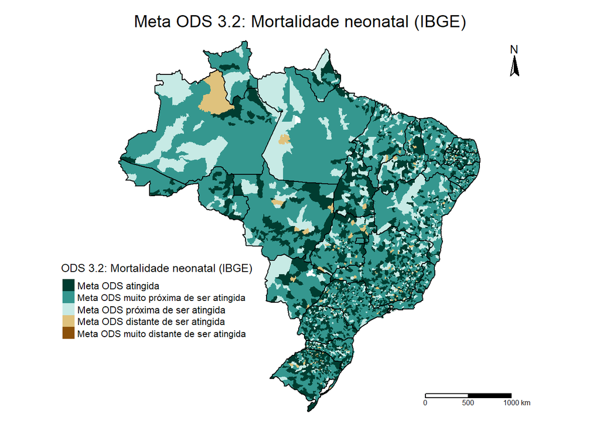

#### Resumo por biomas

ODS Meta 3.2 [Mortalidade neonatal] - Critérios IPEA/IBGE

| Bioma | Nº total de municípios | Meta ODS atingida Nº de municípios | Meta ODS atingida % no bioma | Municípios próximos de atingir a meta ODS Muito próximos Nº de municípios | Municípios próximos de atingir a meta ODS Muito próximos % no bioma | Municípios próximos de atingir a meta ODS Próximos Nº de municípios | Municípios próximos de atingir a meta ODS Próximos % no bioma | Municípios distantes de atingir a meta ODS Distantes Nº de municípios | Municípios distantes de atingir a meta ODS Distantes % no bioma | Municípios distantes de atingir a meta ODS Muito distantes Nº de municípios | Municípios distantes de atingir a meta ODS Muito distantes % no bioma |
| --- | --- | --- | --- | --- | --- | --- | --- | --- | --- | --- | --- |
| Amazonia | 553 | 133 | 24.1% | 327 | 59.1% | 90 | 16.3% | 3 | 0.5% | Não há | Não há |
| Caatinga | 1217 | 412 | 33.9% | 557 | 45.8% | 226 | 18.6% | 22 | 1.8% | Não há | Não há |
| Cerrado | 806 | 333 | 41.3% | 311 | 38.6% | 131 | 16.3% | 31 | 3.8% | Não há | Não há |
| Mata Atlântica | 2875 | 1283 | 44.6% | 1144 | 39.8% | 356 | 12.4% | 88 | 3.1% | 4 | 0.1% |
| Pampa | 94 | 45 | 47.9% | 38 | 40.4% | 7 | 7.4% | 4 | 4.3% | Não há | Não há |
| Pantanal | 19 | 6 | 31.6% | 9 | 47.4% | 3 | 15.8% | 1 | 5.3% | Não há | Não há |

#### Resumo por tipologias

ODS Meta 3.2 [mortalidade neonatal] - Critérios IPEA/IBGE

| Tipologia | Nº total de municípios | Meta ODS atingida Nº de municípios | Meta ODS atingida % no bioma | Municípios próximos de atingir a meta ODS Muito próximos Nº de municípios | Municípios próximos de atingir a meta ODS Muito próximos % no bioma | Municípios próximos de atingir a meta ODS Próximos Nº de municípios | Municípios próximos de atingir a meta ODS Próximos % no bioma | Municípios distantes de atingir a meta ODS Distantes Nº de municípios | Municípios distantes de atingir a meta ODS Distantes % no bioma | Municípios distantes de atingir a meta ODS Muito distantes Nº de municípios | Municípios distantes de atingir a meta ODS Muito distantes % no bioma |
| --- | --- | --- | --- | --- | --- | --- | --- | --- | --- | --- | --- |
| Intermediário | 891 | 202 | 22.7% | 604 | 67.8% | 83 | 9.3% | 2 | 0.2% | Não há | Não há |
| Rural | 4363 | 1991 | 45.6% | 1493 | 34.2% | 728 | 16.7% | 147 | 3.4% | 4 | 0.1% |
| Urbano | 310 | 19 | 6.1% | 289 | 93.2% | 2 | 0.6% | Não há | Não há | Não há | Não há |

### Infantil

**Cortes**

Para determinar as cinco categorias de proximidade do cumprimento do ODS, foi utilizado a classificação de quebras naturais para os grupos que ainda não atingiram a meta do Brasil

- Meta ODS atingida: De 0 a 8 por mil nascidos vivos.
- Meta ODS muito próxima de ser atingida: De 8.01 a 22.6 por mil nascidos vivos.
- Meta ODS próxima de ser atingida: De 22.6 a 46.73 por mil nascidos vivos.
- Meta ODS distante de ser atingida: De 46.73 a 121.21 por mil nascidos vivos.
- Meta ODS muito distante de ser atingida: De 121.21 a 285.71 por mil nascidos vivos.

**Resumo por região**

ODS Meta 3.2 (IBGE) - Mortalidade infantil (2017)

| REGIAO | Meta ODS atingida | Municípios próximos de atingir a meta ODS Meta ODS muito próxima de ser atingida | Municípios próximos de atingir a meta ODS Meta ODS próxima de ser atingida | Municípios distantes de atingir a meta ODS Meta ODS distante de ser atingida | Municípios distantes de atingir a meta ODS Meta ODS muito distante de ser atingida |
| --- | --- | --- | --- | --- | --- |
| Centro-Oeste | 57,9% | 32,2% | 7,9% | 1,9% | Não há |
| Nordeste | 43,3% | 48,6% | 7,6% | 0,5% | Não há |
| Norte | 42,8% | 51,9% | 4,9% | 0,4% | Não há |
| Sudeste | 56,5% | 35,1% | 7,2% | 1,1% | 0,1% |
| Sul | 66,8% | 24,8% | 6,9% | 1,3% | 0,3% |

**Distribuição espacial**

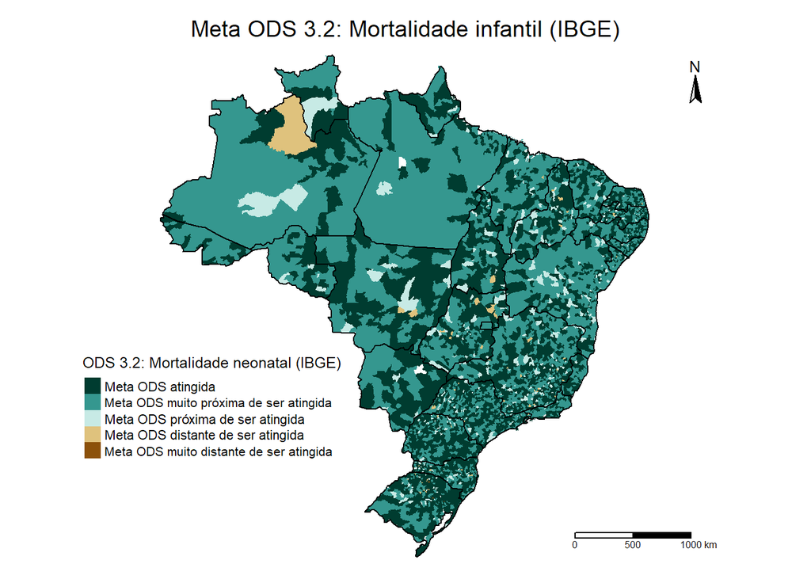

#### Resumo por biomas

ODS Meta 3.2 [Mortalidade infantil] - Critérios IPEA/IBGE

| Bioma | Nº total de municípios | Meta ODS atingida Nº de municípios | Meta ODS atingida % no bioma | Municípios próximos de atingir a meta ODS Muito próximos Nº de municípios | Municípios próximos de atingir a meta ODS Muito próximos % no bioma | Municípios próximos de atingir a meta ODS Próximos Nº de municípios | Municípios próximos de atingir a meta ODS Próximos % no bioma | Municípios distantes de atingir a meta ODS Distantes Nº de municípios | Municípios distantes de atingir a meta ODS Distantes % no bioma | Municípios distantes de atingir a meta ODS Muito distantes Nº de municípios | Municípios distantes de atingir a meta ODS Muito distantes % no bioma |
| --- | --- | --- | --- | --- | --- | --- | --- | --- | --- | --- | --- |
| Amazonia | 553 | 217 | 39.2% | 313 | 56.6% | 22 | 4.0% | 1 | 0.2% | Não há | Não há |
| Caatinga | 1217 | 566 | 46.5% | 551 | 45.3% | 94 | 7.7% | 6 | 0.5% | Não há | Não há |
| Cerrado | 806 | 427 | 53.0% | 293 | 36.4% | 73 | 9.1% | 13 | 1.6% | Não há | Não há |
| Mata Atlântica | 2875 | 1693 | 58.9% | 942 | 32.8% | 202 | 7.0% | 34 | 1.2% | 4 | 0.1% |
| Pampa | 94 | 61 | 64.9% | 27 | 28.7% | 6 | 6.4% | Não há | Não há | Não há | Não há |
| Pantanal | 19 | 9 | 47.4% | 9 | 47.4% | 1 | 5.3% | Não há | Não há | Não há | Não há |

#### Resumo por tipologias

ODS Meta 3.2 [mortalidade infantil] - Critérios IPEA/IBGE

| Tipologia | Nº total de municípios | Meta ODS atingida Nº de municípios | Meta ODS atingida % no bioma | Municípios próximos de atingir a meta ODS Muito próximos Nº de municípios | Municípios próximos de atingir a meta ODS Muito próximos % no bioma | Municípios próximos de atingir a meta ODS Próximos Nº de municípios | Municípios próximos de atingir a meta ODS Próximos % no bioma | Municípios distantes de atingir a meta ODS Distantes Nº de municípios | Municípios distantes de atingir a meta ODS Distantes % no bioma | Municípios distantes de atingir a meta ODS Muito distantes Nº de municípios | Municípios distantes de atingir a meta ODS Muito distantes % no bioma |
| --- | --- | --- | --- | --- | --- | --- | --- | --- | --- | --- | --- |
| Intermediário | 891 | 421 | 47.3% | 450 | 50.5% | 19 | 2.1% | 1 | 0.1% | Não há | Não há |
| Rural | 4363 | 2414 | 55.3% | 1513 | 34.7% | 379 | 8.7% | 53 | 1.2% | 4 | 0.1% |
| Urbano | 310 | 138 | 44.5% | 172 | 55.5% | Não há | Não há | Não há | Não há | Não há | Não há |

# ODS 4 - Educação de qualidade

**ODS 4: Assegurar a educação inclusiva e equitativa e de qualidade, e promover oportunidades de aprendizagem ao longo da vida para todos**

O quarto ODS, associado à educação, será analisado utilizando a meta 4.1. Será utilizado apenas o índice de matrículas no ensino médio de pessoas de 15 a 17 anos (idade de acesso a esse nível considerada adequada) no ano de 2018, uma vez que *“o acesso ao ensino médio representa, atualmente, o maior gargalo dos municípios na promoção da inclusão social pela educação. […] os níveis de acesso ao ensino fundamental encontram-se mais próximos da universalização, de modo que o indicador de acesso ao ensino médio lança luz, com maior profundidade, sobre os desafios da educação de longo prazo enfrentados pelos municípios brasileiros.” (L. F. NOVAIS CONSULTORES LTDA, 2019, p.34)*

- Meta 4.1
  - **ONU**: Até 2030, garantir que todas as meninas e meninos completem o ensino primário e secundário livre, equitativo e de qualidade, que conduza a resultados de aprendizagem relevantes e eficazes.
  - **IBGE/IPEA**: Até 2030, garantir que todas as meninas e meninos completem o ensino fundamental e médio, equitativo e de qualidade, na idade adequada, assegurando a oferta gratuita na rede pública e que conduza a resultados de aprendizagem satisfatórios e relevantes.

O mapa abaixo mostra a distribuição espacial geral dos dados no Brasil:

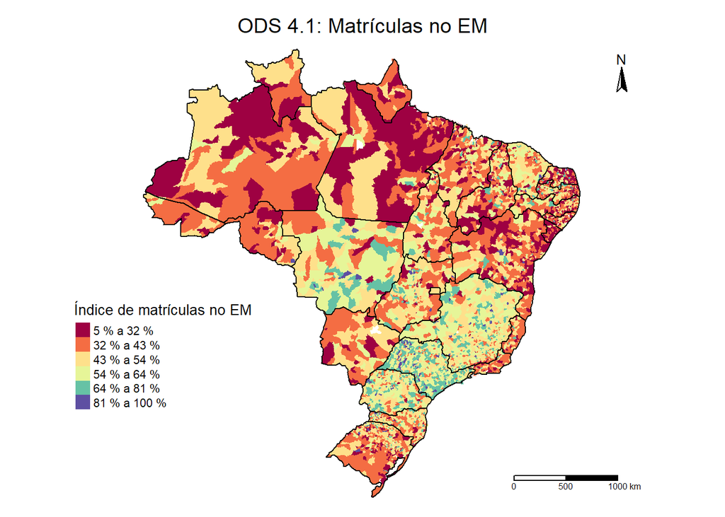

Abaixo, a tabela apresenta as médias de valores por região do Brasil em 2018:

ODS Meta 4.1 - Acesso ao ensino médio (2018)*

| REGIAO | Matrículas no ensino médio |
| --- | --- |
| Centro-Oeste | 49.39% |
| Nordeste | 40.30% |
| Norte | 39.44% |
| Sudeste | 56.19% |
| Sul | 49.81% |

<sup>a</sup> *O índice de matrículas no ensino médio é dado pela porcentagem de pessoas de 15 a 17, matriculadas no ensino médio, residentes no município.

## Critérios únicos (ONU e IBGE/IPEA)

**Cortes**

Para determinar as cinco categorias de proximidade do cumprimento do ODS, foi utilizado a classificação de quebras naturais para os grupos que ainda não atingiram a meta da ONU.

- Meta ODS atingida: 100% das pessoas de 15 a 17 anos residentes no município estão matriculadas no ensino médio.
- Meta ODS muito próxima de ser atingida: De 99.77% a 64.21%.
- Meta ODS próxima de ser atingida: De 64.21% a 49.46%.
- Meta ODS distante de ser atingida: De 49.46% a 36.1%.
- Meta ODS muito distante de ser atingida: De 36.1% a 4.97%.

**Resumo por região**

ODS Meta 4.1 - Acesso ao ensino médio (2018)

| REGIAO | Meta ODS atingida | Municípios próximos de atingir a meta ODS Meta ODS muito próxima de ser atingida | Municípios próximos de atingir a meta ODS Meta ODS próxima de ser atingida | Municípios distantes de atingir a meta ODS Meta ODS distante de ser atingida | Municípios distantes de atingir a meta ODS Meta ODS muito distante de ser atingida |
| --- | --- | --- | --- | --- | --- |
| Centro-Oeste | 0,9% | 10,3% | 35,4% | 39,1% | 14,4% |
| Nordeste | 0,2% | 3,7% | 17,6% | 38,1% | 40,4% |
| Norte | Não há | 2,2% | 15,7% | 40,3% | 41,8% |
| Sudeste | 0,96% | 23,83% | 45,38% | 24,25% | 5,58% |
| Sul | 1,2% | 12,1% | 32,9% | 39,5% | 14,2% |

**Distribuição espacial**

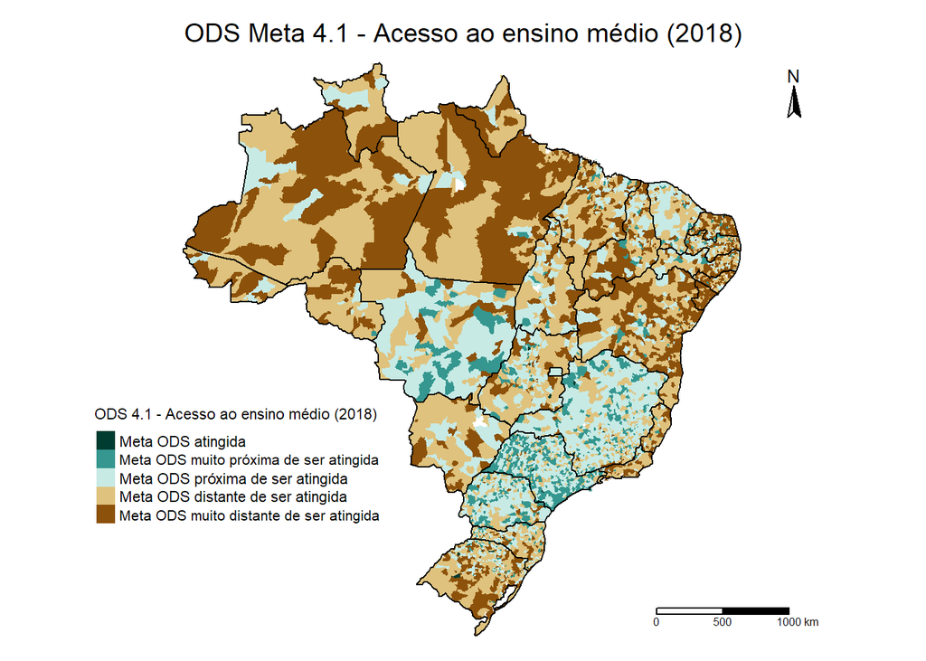

#### Resumo por biomas

ODS Meta 4.1 - Acesso ao ensino médio (2018)

| Bioma | Nº total de municípios | Meta ODS atingida Nº de municípios | Meta ODS atingida % no bioma | Municípios próximos de atingir a meta ODS Muito próximos Nº de municípios | Municípios próximos de atingir a meta ODS Muito próximos % no bioma | Municípios próximos de atingir a meta ODS Próximos Nº de municípios | Municípios próximos de atingir a meta ODS Próximos % no bioma | Municípios distantes de atingir a meta ODS Distantes Nº de municípios | Municípios distantes de atingir a meta ODS Distantes % no bioma | Municípios distantes de atingir a meta ODS Muito distantes Nº de municípios | Municípios distantes de atingir a meta ODS Muito distantes % no bioma |
| --- | --- | --- | --- | --- | --- | --- | --- | --- | --- | --- | --- |
| Amazonia | 553 | Não há | Não há | 27 | 4.9% | 103 | 18.6% | 217 | 39.2% | 206 | 37.3% |
| Caatinga | 1215 | 2 | 0.2% | 58 | 4.8% | 260 | 21.4% | 454 | 37.4% | 441 | 36.3% |
| Cerrado | 803 | 5 | 0.6% | 93 | 11.6% | 303 | 37.7% | 294 | 36.6% | 108 | 13.4% |
| Mata Atlântica | 2870 | 28 | 1.0% | 484 | 16.9% | 1015 | 35.4% | 904 | 31.5% | 439 | 15.3% |
| Pampa | 94 | 2 | 2.1% | 1 | 1.1% | 7 | 7.4% | 44 | 46.8% | 40 | 42.6% |
| Pantanal | 19 | Não há | Não há | 3 | 15.8% | 8 | 42.1% | 4 | 21.1% | 4 | 21.1% |

#### Resumo por tipologias

ODS Meta 4.1 - Acesso ao ensino médio (2018)

| Tipologia | Nº total de municípios | Meta ODS atingida Nº de municípios | Meta ODS atingida % no bioma | Municípios próximos de atingir a meta ODS Muito próximos Nº de municípios | Municípios próximos de atingir a meta ODS Muito próximos % no bioma | Municípios próximos de atingir a meta ODS Próximos Nº de municípios | Municípios próximos de atingir a meta ODS Próximos % no bioma | Municípios distantes de atingir a meta ODS Distantes Nº de municípios | Municípios distantes de atingir a meta ODS Distantes % no bioma | Municípios distantes de atingir a meta ODS Muito distantes Nº de municípios | Municípios distantes de atingir a meta ODS Muito distantes % no bioma |
| --- | --- | --- | --- | --- | --- | --- | --- | --- | --- | --- | --- |
| Intermediário | 891 | 2 | 0.2% | 104 | 11.7% | 252 | 28.3% | 312 | 35.0% | 220 | 24.7% |
| Rural | 4363 | 34 | 0.8% | 517 | 11.8% | 1317 | 30.2% | 1497 | 34.3% | 989 | 22.7% |
| Urbano | 310 | 1 | 0.3% | 45 | 14.5% | 127 | 41.0% | 108 | 34.8% | 29 | 9.4% |

# ODS 5 - Igualdade de gênero

**ODS 5: Alcançar a igualdade de gênero e empoderar todas as mulheres e meninas**

O quinto ODS, que trata da igualdade de gênero, será analisado utilizando a meta 5.5, que trata da participação de mulheres e igualdade de oportunidades em posições de liderança. Como indicador de referência tem-se a proporção de mulheres eleitas para mandato legislativo municipal em 2016.

- Meta 5.5
  - **ONU**: Garantir a participação plena e efetiva das mulheres e a igualdade de oportunidades para a liderança em todos os níveis de tomada de decisão na vida política, econômica e pública.
  - **IBGE/IPEA**: Garantir a participação plena e efetiva das mulheres e a igualdade de oportunidades para a liderança em todos os níveis de tomada de decisão na esfera pública, em suas dimensões política e econômica, considerando as intersecções com raça, etnia, idade, deficiência, orientação sexual, identidade de gênero, territorialidade, cultura, religião e nacionalidade, em especial para as mulheres do campo, da floresta, das águas e das periferias urbanas.

Uma vez que não há na meta a determinação de cortes para o cumprimento do objetivo específico e, legalmente, o Brasil não possui a determinação de cotas mínimas de mulheres eleitas, optou-se por adotar o mesmo parâmetro dado pela [Lei 9.504/1997](http://www.planalto.gov.br/ccivil_03/leis/l9504.htm) relativo à paridade de gênero nas candidaturas, sendo considerado nesta análise que a meta foi cumprida quando a proporção de mulheres eleitas foi superior a 30%.

O mapa abaixo mostra a distribuição espacial geral dos dados no Brasil:

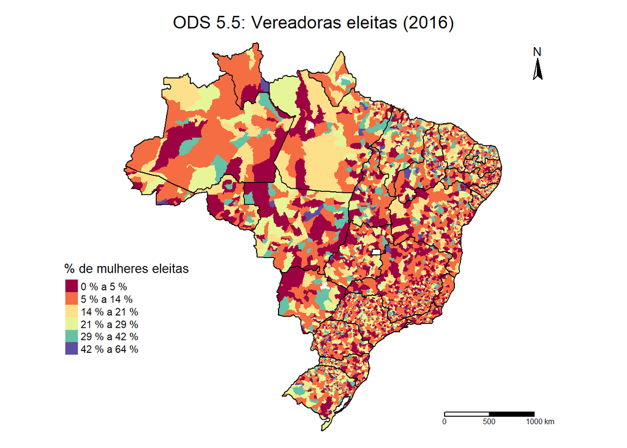

Abaixo, a tabela apresenta as médias de valores por região do Brasil em 2016:

ODS Meta 5.5 - Vereadoras eleitas (2016)

| REGIAO | % de vereadoras eleitas em 2016 |
| --- | --- |
| Centro-Oeste | 13.22% |
| Nordeste | 15.32% |
| Norte | 14.15% |
| Sudeste | 11.47% |
| Sul | 14.45% |

## Critérios únicos (ONU e IBGE/IPEA)

**Cortes**

Para determinar as cinco categorias de proximidade do cumprimento do ODS, foi utilizado a classificação de quebras naturais para os grupos que ainda não atingiram a meta da ONU.

- Meta ODS atingida: Ao menos 30% de cadeiras ocupadas por mulheres no legislativo municipal.
- Meta ODS muito próxima de ser atingida: De 29.41% a 20% .
- Meta ODS próxima de ser atingida: De 20% a 13.79%.
- Meta ODS distante de ser atingida: De 13.79% a 4.76%.
- Meta ODS muito distante de ser atingida: De 4.76% a 0%.

**Resumo por região**

ODS Meta 5.5 - Vereadoras eleitas (2016)

| REGIAO | Meta ODS atingida | Municípios próximos de atingir a meta ODS Meta ODS muito próxima de ser atingida | Municípios próximos de atingir a meta ODS Meta ODS próxima de ser atingida | Municípios distantes de atingir a meta ODS Meta ODS distante de ser atingida | Municípios distantes de atingir a meta ODS Meta ODS muito distante de ser atingida |
| --- | --- | --- | --- | --- | --- |
| Centro-Oeste | 9,5% | 22,4% | 7,1% | 33,3% | 27,7% |
| Nordeste | 12,50% | 21,21% | 11,77% | 35,10% | 19,42% |
| Norte | 11,61% | 15,40% | 12,05% | 42,19% | 18,75% |
| Sudeste | 6,7% | 17,7% | 5,5% | 40,5% | 29,6% |
| Sul | 11,0% | 25,7% | 4,4% | 37,6% | 21,3% |

**Distribuição espacial**

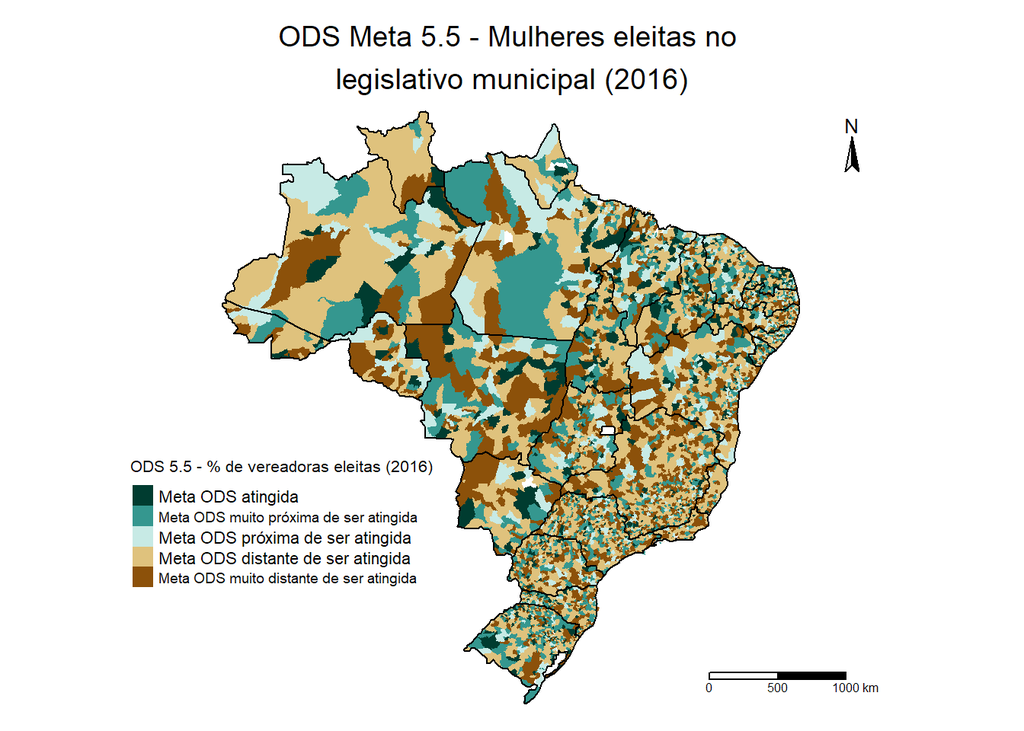

#### Resumo por biomas

ODS Meta 5.5 - Vereadoras eleitas (2016)

| Bioma | Nº total de municípios | Meta ODS atingida Nº de municípios | Meta ODS atingida % no bioma | Municípios próximos de atingir a meta ODS Muito próximos Nº de municípios | Municípios próximos de atingir a meta ODS Muito próximos % no bioma | Municípios próximos de atingir a meta ODS Próximos Nº de municípios | Municípios próximos de atingir a meta ODS Próximos % no bioma | Municípios distantes de atingir a meta ODS Distantes Nº de municípios | Municípios distantes de atingir a meta ODS Distantes % no bioma | Municípios distantes de atingir a meta ODS Muito distantes Nº de municípios | Municípios distantes de atingir a meta ODS Muito distantes % no bioma |
| --- | --- | --- | --- | --- | --- | --- | --- | --- | --- | --- | --- |
| Amazonia | 552 | 64 | 11.6% | 92 | 16.7% | 76 | 13.8% | 205 | 37.1% | 115 | 20.8% |
| Caatinga | 1217 | 161 | 13.2% | 262 | 21.5% | 121 | 9.9% | 447 | 36.7% | 226 | 18.6% |
| Cerrado | 805 | 83 | 10.3% | 170 | 21.1% | 59 | 7.3% | 290 | 36.0% | 203 | 25.2% |
| Mata Atlântica | 2874 | 242 | 8.4% | 603 | 21.0% | 175 | 6.1% | 1112 | 38.7% | 742 | 25.8% |
| Pampa | 94 | 12 | 12.8% | 25 | 26.6% | 9 | 9.6% | 33 | 35.1% | 15 | 16.0% |
| Pantanal | 19 | 1 | 5.3% | 1 | 5.3% | 2 | 10.5% | 8 | 42.1% | 7 | 36.8% |

#### Resumo por tipologias

ODS Meta 5.5 - Vereadoras eleitas (2016)

| Tipologia | Nº total de municípios | Meta ODS atingida Nº de municípios | Meta ODS atingida % no bioma | Municípios próximos de atingir a meta ODS Muito próximos Nº de municípios | Municípios próximos de atingir a meta ODS Muito próximos % no bioma | Municípios próximos de atingir a meta ODS Próximos Nº de municípios | Municípios próximos de atingir a meta ODS Próximos % no bioma | Municípios distantes de atingir a meta ODS Distantes Nº de municípios | Municípios distantes de atingir a meta ODS Distantes % no bioma | Municípios distantes de atingir a meta ODS Muito distantes Nº de municípios | Municípios distantes de atingir a meta ODS Muito distantes % no bioma |
| --- | --- | --- | --- | --- | --- | --- | --- | --- | --- | --- | --- |
| Intermediário | 891 | 52 | 5.8% | 178 | 20.0% | 121 | 13.6% | 356 | 40.0% | 183 | 20.5% |
| Rural | 4363 | 508 | 11.6% | 939 | 21.5% | 268 | 6.1% | 1579 | 36.2% | 1068 | 24.5% |
| Urbano | 310 | 3 | 1.0% | 36 | 11.6% | 53 | 17.1% | 160 | 51.6% | 57 | 18.4% |

# ODS 6 - Água potável e saneamento

**ODS 6: Assegurar a disponibilidade e gestão sustentável da água e saneamento para todas e todos**

O sexto ODS, que trata da temática do acesso a água potável e saneamento, será analisado utilizando a meta 6.1, que trata do acesso à água própria para o consumo humano, fazendo uso do indicador de porcentagem da população municipal atendida por fontes seguras de abastecimento de água (rede de abastecimento).

- Meta 6.1
  - **ONU**: Até 2030, alcançar o acesso universal e equitativo a água potável e segura para todos.
  - **IBGE/IPEA**: Até 2030, alcançar o acesso universal e equitativo à água para consumo humano, segura e acessível para todas e todos.

Uma vez que não há na meta a determinação de corte específico para o cumprimento do objetivo, será adotado como municípios que atingiram a meta aqueles que apresentaram no mínimo 99% de atendimento no ano de 2016.

O mapa abaixo mostra a distribuição espacial geral dos dados no Brasil:

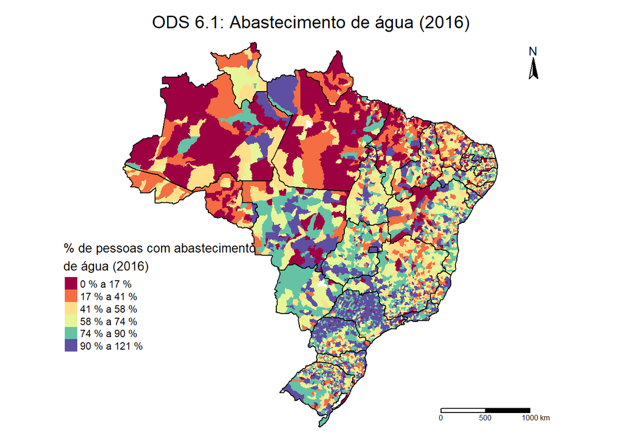

Abaixo, a tabela apresenta as médias de valores por região do Brasil em 2016:

ODS Meta 6.1 - Abastecimento de água (2016)

| REGIAO | % de pessoas atendidas por fontes seguras de abastecimento de água |
| --- | --- |
| Centro-Oeste | 69.93% |
| Nordeste | 54.15% |
| Norte | 41.33% |
| Sudeste | 72.66% |
| Sul | 71.34% |

## Critérios únicos (ONU e IBGE/IPEA)

**Cortes**

Para determinar as cinco categorias de proximidade do cumprimento do ODS, foi utilizado a classificação de quebras naturais para os grupos que ainda não atingiram a meta da ONU.

- Meta ODS atingida: 99% a 100% da população municipal atendida por fontes seguras de abastecimento de água (rede de abastecimento).
- Meta ODS muito próxima de ser atingida: De 99% a 75.97% .
- Meta ODS próxima de ser atingida: De 75.97% a 51.35%.
- Meta ODS distante de ser atingida: De 51.35% a 20.81%.
- Meta ODS muito distante de ser atingida: De 20.81% a 0%.

**Resumo por região**

ODS Meta 6.1 - Abastecimento de água (2016)

| REGIAO | Meta ODS atingida | Municípios próximos de atingir a meta ODS Meta ODS muito próxima de ser atingida | Municípios próximos de atingir a meta ODS Meta ODS próxima de ser atingida | Municípios distantes de atingir a meta ODS Meta ODS distante de ser atingida | Municípios distantes de atingir a meta ODS Meta ODS muito distante de ser atingida |
| --- | --- | --- | --- | --- | --- |
| Centro-Oeste | 8,15% | 41,42% | 33,05% | 9,66% | 7,73% |
| Nordeste | 6,2% | 20,9% | 29,8% | 26,9% | 16,2% |
| Norte | 3,79% | 13,14% | 24,50% | 24,94% | 33,63% |
| Sudeste | 12,89% | 40,41% | 29,80% | 12,41% | 4,50% |
| Sul | 19,7% | 32,4% | 24,9% | 17,4% | 5,6% |

**Distribuição espacial**

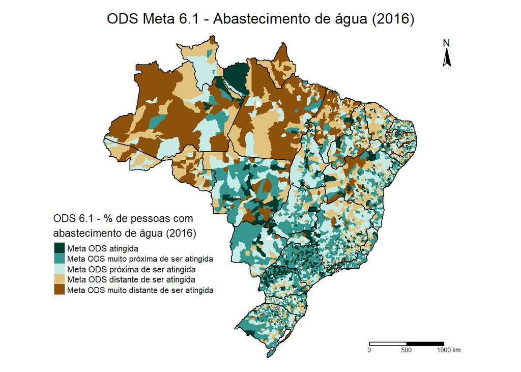

#### Resumo por biomas

ODS Meta 6.1 - Abastecimento de água (2016)

| Bioma | Nº total de municípios | Meta ODS atingida Nº de municípios | Meta ODS atingida % no bioma | Municípios próximos de atingir a meta ODS Muito próximos Nº de municípios | Municípios próximos de atingir a meta ODS Muito próximos % no bioma | Municípios próximos de atingir a meta ODS Próximos Nº de municípios | Municípios próximos de atingir a meta ODS Próximos % no bioma | Municípios distantes de atingir a meta ODS Distantes Nº de municípios | Municípios distantes de atingir a meta ODS Distantes % no bioma | Municípios distantes de atingir a meta ODS Muito distantes Nº de municípios | Municípios distantes de atingir a meta ODS Muito distantes % no bioma |
| --- | --- | --- | --- | --- | --- | --- | --- | --- | --- | --- | --- |
| Amazonia | 553 | 23 | 4.2% | 78 | 14.1% | 92 | 16.6% | 136 | 24.6% | 224 | 40.5% |
| Caatinga | 1217 | 66 | 5.4% | 238 | 19.6% | 391 | 32.1% | 346 | 28.4% | 176 | 14.5% |
| Cerrado | 806 | 81 | 10.0% | 262 | 32.5% | 269 | 33.4% | 126 | 15.6% | 68 | 8.4% |
| Mata Atlântica | 2875 | 433 | 15.1% | 1060 | 36.9% | 815 | 28.3% | 428 | 14.9% | 139 | 4.8% |
| Pampa | 94 | 10 | 10.6% | 39 | 41.5% | 19 | 20.2% | 16 | 17.0% | 10 | 10.6% |
| Pantanal | 19 | 2 | 10.5% | 9 | 47.4% | 5 | 26.3% | 1 | 5.3% | 2 | 10.5% |

#### Resumo por tipologias

ODS Meta 6.1 - Abastecimento de água (2016)

| Tipologia | Nº total de municípios | Meta ODS atingida Nº de municípios | Meta ODS atingida % no bioma | Municípios próximos de atingir a meta ODS Muito próximos Nº de municípios | Municípios próximos de atingir a meta ODS Muito próximos % no bioma | Municípios próximos de atingir a meta ODS Próximos Nº de municípios | Municípios próximos de atingir a meta ODS Próximos % no bioma | Municípios distantes de atingir a meta ODS Distantes Nº de municípios | Municípios distantes de atingir a meta ODS Distantes % no bioma | Municípios distantes de atingir a meta ODS Muito distantes Nº de municípios | Municípios distantes de atingir a meta ODS Muito distantes % no bioma |
| --- | --- | --- | --- | --- | --- | --- | --- | --- | --- | --- | --- |
| Intermediário | 891 | 137 | 15.4% | 385 | 43.2% | 195 | 21.9% | 104 | 11.7% | 70 | 7.9% |
| Rural | 4363 | 372 | 8.5% | 1132 | 25.9% | 1378 | 31.6% | 937 | 21.5% | 544 | 12.5% |
| Urbano | 310 | 106 | 34.2% | 169 | 54.5% | 18 | 5.8% | 12 | 3.9% | 5 | 1.6% |

# ODS 8 - Trabalho decente e crescimento econômico

**ODS 8: Promover o crescimento econômico sustentado, inclusivo e sustentável, emprego pleno e produtivo, e trabalho decente para todos e todas**

- Meta 8.1
  - **ONU**: Sustentar o crescimento econômico per capita, de acordo com as circunstâncias nacionais e, em particular, pelo menos um crescimento anual de 7% do produto interno bruto nos países de menor desenvolvimento relativo.
  - **IBGE/IPEA**: Registrar um crescimento econômico per capita anual médio de 1,6% entre 2016 e 2018; e de 2,55% entre 2019 e 2030.
- Meta 8.2
  - **ONU**: Atingir níveis mais elevados de produtividade das economias, por meio da diversificação, modernização tecnológica e inovação, inclusive por meio de um foco em setores de alto valor agregado e intensivos em mão-de-obra.
  - **IBGE/IPEA**: Atingir níveis mais elevados de produtividade, por meio da diversificação e com agregação de valor, modernização tecnológica, inovação, gestão, e qualificação do trabalhador; com foco em setores intensivos em mão-de-obra.

O mapa abaixo mostra a distribuição espacial geral dos dados no Brasil:

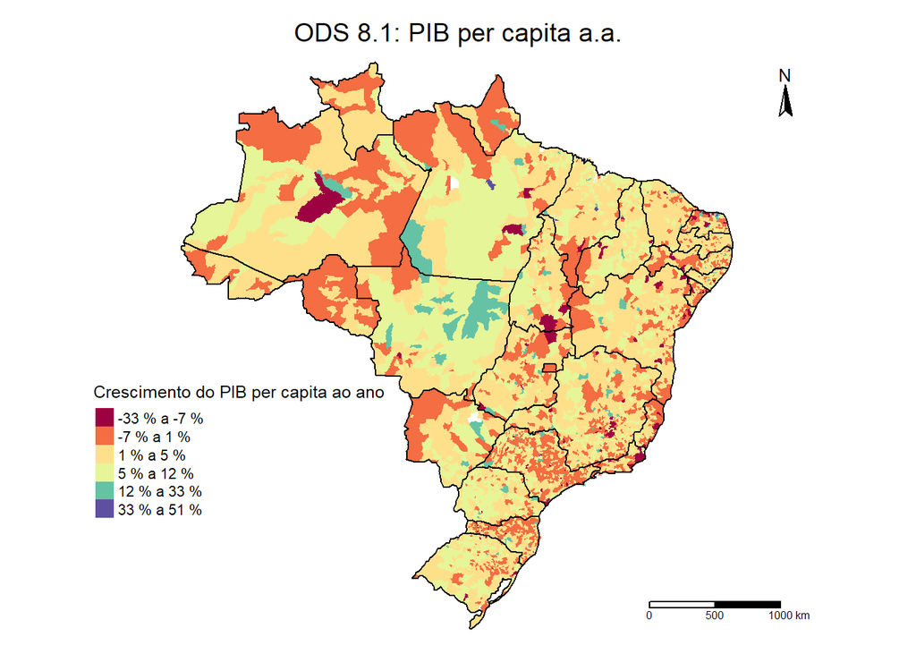

ODS Meta 8.1 - Tx. média de crescimento anual do PIB (2010-2016)

| REGIAO | Tx. de crescimento anual do PIB entre 2010 e 2016 |
| --- | --- |
| Centro-Oeste | 3.55% |
| Nordeste | 2.42% |
| Norte | 2.65% |
| Sudeste | 1.50% |
| Sul | 3.17% |

## Critérios ONU

**Cortes**

Para determinar as cinco categorias de proximidade do cumprimento do ODS, foi utilizado a classificação de quebras naturais para os grupos que ainda não atingiram a meta da ONU.

- Meta ODS atingida: Crescimento anual de ao menos 7% do produto interno bruto.
- Meta ODS muito próxima de ser atingida: Crescimento de 7% a 2.97% .
- Meta ODS próxima de ser atingida: Crescimento de 2.97% a -0.57%.
- Meta ODS distante de ser atingida: Crescimento de -0.57% a -7.65%.
- Meta ODS muito distante de ser atingida: Crescimento de -7.65% a -32.94%.

**Resumo por região**

ODS Meta 8.1 (ONU) - Tx. de crescimento anual do PIB (2010-2016)

| REGIAO | Meta ODS atingida | Municípios próximos de atingir a meta ODS Meta ODS muito próxima de ser atingida | Municípios próximos de atingir a meta ODS Meta ODS próxima de ser atingida | Municípios distantes de atingir a meta ODS Meta ODS distante de ser atingida | Municípios distantes de atingir a meta ODS Meta ODS muito distante de ser atingida |
| --- | --- | --- | --- | --- | --- |
| Centro-Oeste | 18,9% | 29,8% | 37,3% | 12,7% | 1,3% |
| Nordeste | 5,4% | 34,7% | 48,2% | 9,7% | 2,0% |
| Norte | 8,9% | 35,9% | 40,3% | 13,6% | 1,3% |
| Sudeste | 6,4% | 26,1% | 41,1% | 23,5% | 2,9% |
| Sul | 12,54% | 41,84% | 32,24% | 12,12% | 1,26% |

**Distribuição espacial**

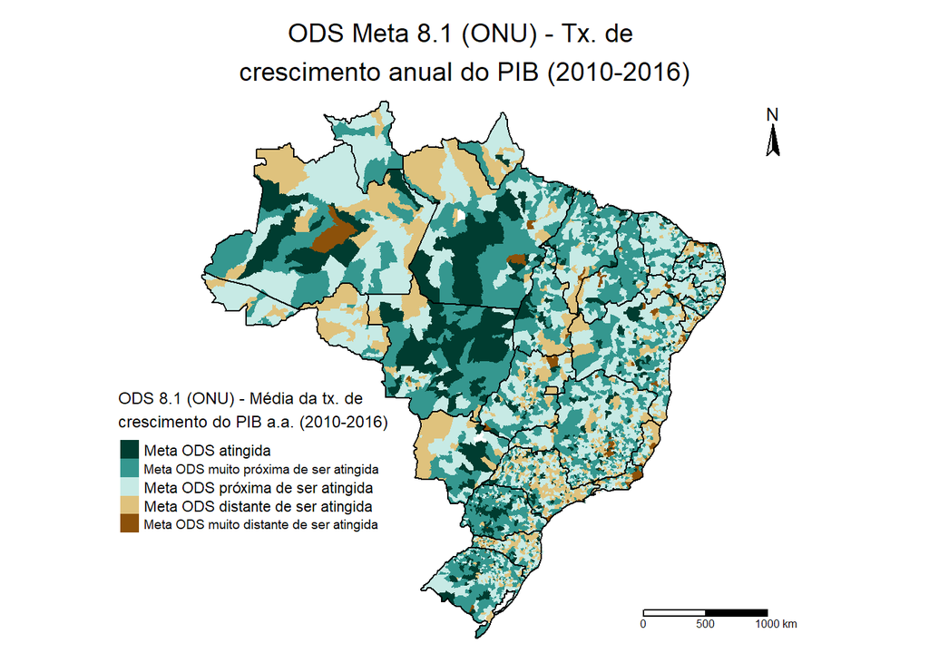

#### Resumo por biomas

ODS Meta 8.1 (ONU) - Tx. de crescimento anual do PIB (2010-2016)

| Bioma | Nº total de municípios | Meta ODS atingida Nº de municípios | Meta ODS atingida % no bioma | Municípios próximos de atingir a meta ODS Muito próximos Nº de municípios | Municípios próximos de atingir a meta ODS Muito próximos % no bioma | Municípios próximos de atingir a meta ODS Próximos Nº de municípios | Municípios próximos de atingir a meta ODS Próximos % no bioma | Municípios distantes de atingir a meta ODS Distantes Nº de municípios | Municípios distantes de atingir a meta ODS Distantes % no bioma | Municípios distantes de atingir a meta ODS Muito distantes Nº de municípios | Municípios distantes de atingir a meta ODS Muito distantes % no bioma |
| --- | --- | --- | --- | --- | --- | --- | --- | --- | --- | --- | --- |
| Amazonia | 553 | 81 | 14.6% | 220 | 39.8% | 185 | 33.5% | 62 | 11.2% | 5 | 0.9% |
| Caatinga | 1217 | 60 | 4.9% | 413 | 33.9% | 633 | 52.0% | 92 | 7.6% | 19 | 1.6% |
| Cerrado | 806 | 78 | 9.7% | 259 | 32.1% | 331 | 41.1% | 127 | 15.8% | 11 | 1.4% |
| Mata Atlântica | 2875 | 251 | 8.7% | 920 | 32.0% | 1092 | 38.0% | 538 | 18.7% | 74 | 2.6% |
| Pampa | 94 | 7 | 7.4% | 41 | 43.6% | 38 | 40.4% | 7 | 7.4% | 1 | 1.1% |
| Pantanal | 19 | 3 | 15.8% | 2 | 10.5% | 10 | 52.6% | 4 | 21.1% | Não há | Não há |

#### Resumo por tipologias

ODS Meta 8.1 - Tx. de crescimento anual do PIB (2010-2016)

| Tipologia | Nº total de municípios | Meta ODS atingida Nº de municípios | Meta ODS atingida % no bioma | Municípios próximos de atingir a meta ODS Muito próximos Nº de municípios | Municípios próximos de atingir a meta ODS Muito próximos % no bioma | Municípios próximos de atingir a meta ODS Próximos Nº de municípios | Municípios próximos de atingir a meta ODS Próximos % no bioma | Municípios distantes de atingir a meta ODS Distantes Nº de municípios | Municípios distantes de atingir a meta ODS Distantes % no bioma | Municípios distantes de atingir a meta ODS Muito distantes Nº de municípios | Municípios distantes de atingir a meta ODS Muito distantes % no bioma |
| --- | --- | --- | --- | --- | --- | --- | --- | --- | --- | --- | --- |
| Intermediário | 891 | 50 | 5.6% | 225 | 25.3% | 401 | 45.0% | 187 | 21.0% | 28 | 3.1% |
| Rural | 4363 | 425 | 9.7% | 1586 | 36.4% | 1738 | 39.8% | 540 | 12.4% | 74 | 1.7% |
| Urbano | 310 | 5 | 1.6% | 44 | 14.2% | 150 | 48.4% | 103 | 33.2% | 8 | 2.6% |

## Critérios IBGE/IPEA

**Cortes**

Para determinar as cinco categorias de proximidade do cumprimento do ODS, foi utilizado a classificação de quebras naturais para os grupos que ainda não atingiram a meta do IBGE/IPEA.

- Meta ODS atingida: Crescimento anual do produto interno bruto de ao menos 1.6%.
- Meta ODS muito próxima de ser atingida: Crescimento de 1.6% a -0.88% .
- Meta ODS próxima de ser atingida: Crescimento de -0.88% a -4.68%.
- Meta ODS distante de ser atingida: Crescimento de -4.68% a -11.61%.
- Meta ODS muito distante de ser atingida: Crescimento de -11.61% a -32.94%.

**Resumo por região**

ODS Meta 8.1 (IBGE) - Tx. de crescimento anual do PIB (2010-2016)

| REGIAO | Meta ODS atingida | Municípios próximos de atingir a meta ODS Meta ODS muito próxima de ser atingida | Municípios próximos de atingir a meta ODS Meta ODS próxima de ser atingida | Municípios distantes de atingir a meta ODS Meta ODS distante de ser atingida | Municípios distantes de atingir a meta ODS Meta ODS muito distante de ser atingida |
| --- | --- | --- | --- | --- | --- |
| Centro-Oeste | 65,7% | 22,7% | 8,8% | 2,4% | 0,4% |
| Nordeste | 63,6% | 25,9% | 7,2% | 2,5% | 0,8% |
| Norte | 62,6% | 24,7% | 8,0% | 3,8% | 0,9% |
| Sudeste | 51,3% | 24,6% | 18,5% | 4,4% | 1,2% |
| Sul | 69,9% | 18,3% | 9,4% | 1,9% | 0,6% |

**Distribuição espacial**

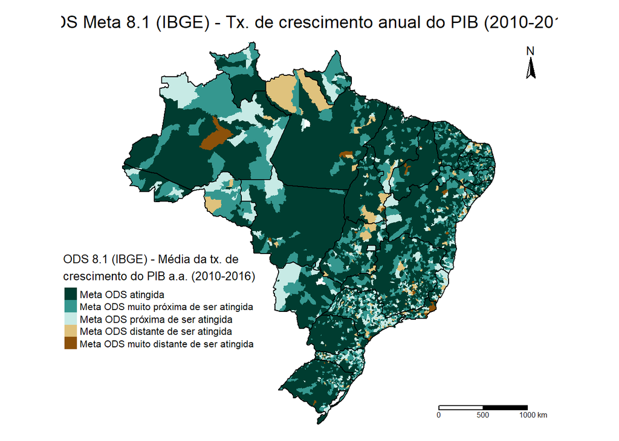

#### Resumo por biomas

ODS Meta 8.1 (IBGE) - Tx. de crescimento anual do PIB (2010-2016)

| Bioma | Nº total de municípios | Meta ODS atingida Nº de municípios | Meta ODS atingida % no bioma | Municípios próximos de atingir a meta ODS Muito próximos Nº de municípios | Municípios próximos de atingir a meta ODS Muito próximos % no bioma | Municípios próximos de atingir a meta ODS Próximos Nº de municípios | Municípios próximos de atingir a meta ODS Próximos % no bioma | Municípios distantes de atingir a meta ODS Distantes Nº de municípios | Municípios distantes de atingir a meta ODS Distantes % no bioma | Municípios distantes de atingir a meta ODS Muito distantes Nº de municípios | Municípios distantes de atingir a meta ODS Muito distantes % no bioma |
| --- | --- | --- | --- | --- | --- | --- | --- | --- | --- | --- | --- |
| Amazonia | 553 | 378 | 68.4% | 118 | 21.3% | 43 | 7.8% | 11 | 2.0% | 3 | 0.5% |
| Caatinga | 1217 | 786 | 64.6% | 335 | 27.5% | 64 | 5.3% | 25 | 2.1% | 7 | 0.6% |
| Cerrado | 806 | 504 | 62.5% | 181 | 22.5% | 91 | 11.3% | 26 | 3.2% | 4 | 0.5% |
| Mata Atlântica | 2875 | 1670 | 58.1% | 646 | 22.5% | 420 | 14.6% | 106 | 3.7% | 33 | 1.1% |
| Pampa | 94 | 64 | 68.1% | 23 | 24.5% | 6 | 6.4% | Não há | Não há | 1 | 1.1% |
| Pantanal | 19 | 10 | 52.6% | 6 | 31.6% | 3 | 15.8% | Não há | Não há | Não há | Não há |

#### Resumo por tipologias

ODS Meta 8.1 - Tx. de crescimento anual do PIB (2010-2016)

| Tipologia | Nº total de municípios | Meta ODS atingida Nº de municípios | Meta ODS atingida % no bioma | Municípios próximos de atingir a meta ODS Muito próximos Nº de municípios | Municípios próximos de atingir a meta ODS Muito próximos % no bioma | Municípios próximos de atingir a meta ODS Próximos Nº de municípios | Municípios próximos de atingir a meta ODS Próximos % no bioma | Municípios distantes de atingir a meta ODS Distantes Nº de municípios | Municípios distantes de atingir a meta ODS Distantes % no bioma | Municípios distantes de atingir a meta ODS Muito distantes Nº de municípios | Municípios distantes de atingir a meta ODS Muito distantes % no bioma |
| --- | --- | --- | --- | --- | --- | --- | --- | --- | --- | --- | --- |
| Intermediário | 891 | 456 | 51.2% | 240 | 26.9% | 147 | 16.5% | 38 | 4.3% | 10 | 1.1% |
| Rural | 4363 | 2859 | 65.5% | 955 | 21.9% | 403 | 9.2% | 112 | 2.6% | 34 | 0.8% |
| Urbano | 310 | 97 | 31.3% | 114 | 36.8% | 77 | 24.8% | 18 | 5.8% | 4 | 1.3% |

# ODS 16 - Paz, justiça e instituições eficazes

**ODS 16: Promover sociedades pacíficas e inclusivas para o desenvolvimento sustentável, proporcionar o acesso à justiça para todos e construir instituições eficazes, responsáveis e inclusivas em todos os níveis**

O ODS 16 será analisado a partir da meta 16.1, por meio da análise das taxas de mortalidade por homicídio intencional de dois grupos específicos (mulheres e pessoas negros (pretos e pardos), além dos totais.

- Meta 16.1:
  - **ONU:** Reduzir significativamente todas as formas de violência e as taxas de mortalidade relacionadas, em todos os lugares.
  - **IBGE/IPEA:** Reduzir significativamente todas as formas de violência e as taxas de mortalidade relacionadas, em todos os lugares, inclusive com a redução de 1/3 das taxas de feminicídio e de homicídios de crianças, adolescentes, jovens, pessoas negras, indígenas, mulheres e LGBT.

Como a meta original da ONU não apresenta indicadores, será analisada apenas a meta determinada pelo IBGE/IPEA. Uma vez que a redução de 1/3 na taxa de mortalidade de pessoas entre minorias sociais não é um indicador absoluto, mas relativo ao seu ano de elaboração, para fins de comparação foi adotada a média de mortalidade de cada estado no ano de 2015, segmentada pelos dois grupos sociais analisados. Dessa maneira, serão considerados como municípios que já atingiram a meta aqueles que apresentarem redução superior a 33% na taxa de homicídio intencional por 100.000 habitantes de 2015 para 2017 ou que apresentarem taxa de 0% em 2017. Os demais municípios foram divididos em 4 categorias, por quebras naturais.

É importante ressaltar três pontos metodológicos:

- Nos casos em que a taxa de mortalidade por homicídio intencional apresentava valores nulos em ambos os anos (2015 e 2017), a meta foi considerada como atingida;
- Há uma quantidade expressiva de municípios em que a taxa de mortalidade por homicídio intencional apresentava valor nulo em 2015, mas valor não nulo em 2017. Visto que não há a possibilidade de estimar aumento ou redução percentual a partir de um valor inicial nulo, a média estadual foi adotada como linha de base (à indicação do IPEA).
- Entre os anos de 2015 e 2017, o dado de mortalidade por violência de indígenas estava zerado para a grande maioria de municípios (aproximadamente 97%), não sendo possível distinguir se isso representa realmente ausência de ocorrências ou ausência de informações. Dessa maneira, a média estadual da taxa de mortalidade indígena ficou distorcida, inviabilizando a comparação entre os dois anos, bem como análise em relação ao cumprimento da meta ODS. Uma vez que a base utilizada para este trabalho não estabelece a distinção se os valores nulos são devido a não ocorrência ou a ausência de dados, para analisar este caso específico seria mais apropriada uma análise focal, revisitando os dados brutos.

O mapa abaixo mostra a distribuição espacial geral dos dados no Brasil:

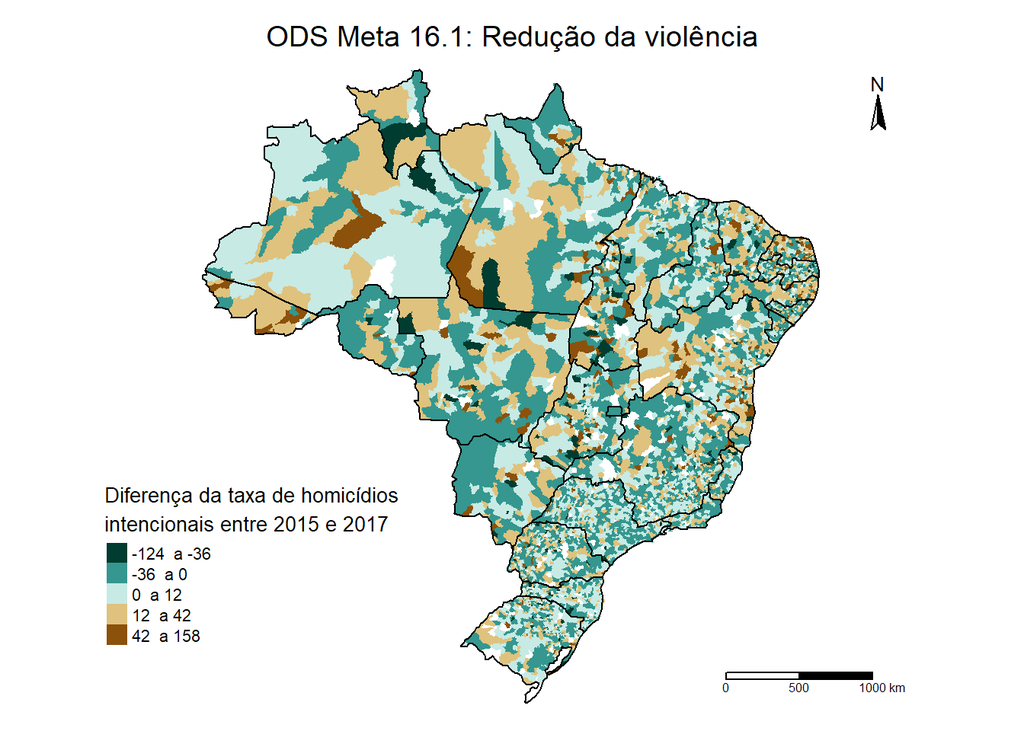

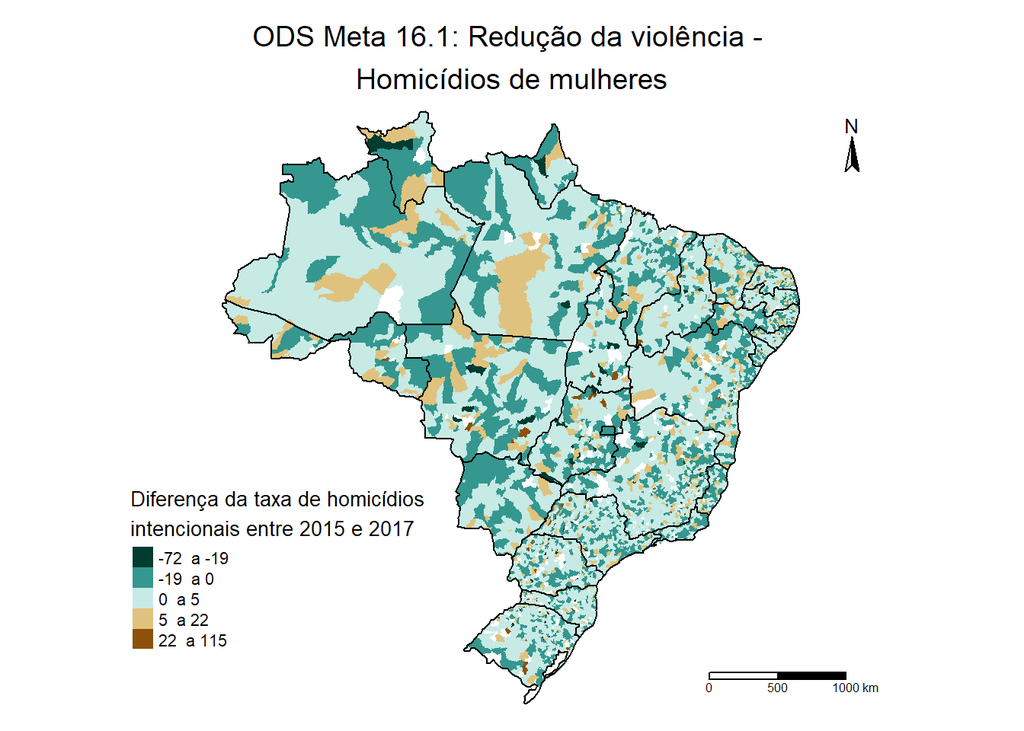

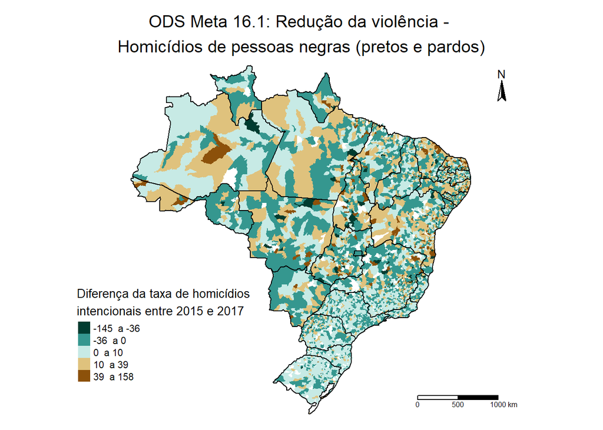

Os valores negativos representam uma redução na taxa de homicídios a cada 100 mil habitantes por município, entre os anos de 2015 e 2017.

Abaixo, a tabela apresenta as médias de valores por região do Brasil:

ODS 16.1: Redução da violência - Diferença média da taxa de homicídios (2015 a 2017)

| REGIAO | Homicídios totais | Homicídio de mulheres | Homicídios de pessoas negras |
| --- | --- | --- | --- |
| Centro-Oeste | 2.95 | -0.11 | 2.69 |
| Nordeste | 6.35 | 0.53 | 6.66 |
| Norte | 6.60 | -0.15 | 4.66 |
| Sudeste | 1.06 | 0.30 | 0.57 |
| Sul | 1.39 | 0.23 | 0.51 |

## Critérios únicos (IBGE/IPEA) - Totais

**Cortes**

- Meta ODS atingida: Decrescimento de ao menos 33% na taxa de mortalidade por homicídio intencional de 2015 para 2017 ou taxa zerada em 2017.
- Meta ODS muito próxima de ser atingida: Evolução da taxa de -32.95% a -15.76%.
- Meta ODS próxima de ser atingida: Evolução da taxa de -15.76% a 0%.
- Meta ODS distante de ser atingida: Evolução da taxa de 0% a 185.78%.
- Meta ODS muito distante de ser atingida: Evolução da taxa de 185.78% a 1195.74%.

**Resumo por região**

ODS Meta 16.1: Redução da violência - Homicídios totais (2015 a 2017)

| REGIAO | Meta ODS atingida | Municípios próximos de atingir a meta ODS Meta ODS muito próxima de ser atingida | Municípios próximos de atingir a meta ODS Meta ODS próxima de ser atingida | Municípios distantes de atingir a meta ODS Meta ODS distante de ser atingida | Municípios distantes de atingir a meta ODS Meta ODS muito distante de ser atingida |
| --- | --- | --- | --- | --- | --- |
| Centro-Oeste | 34,55% | 7,08% | 7,73% | 45,06% | 5,58% |
| Nordeste | 34,19% | 6,86% | 6,69% | 44,79% | 7,47% |
| Norte | 31,0% | 6,2% | 7,8% | 48,8% | 6,2% |
| Sudeste | 45,86% | 5,64% | 6,29% | 34,53% | 7,67% |
| Sul | 49,7% | 5,0% | 3,1% | 31,4% | 10,8% |

**Distribuição espacial**

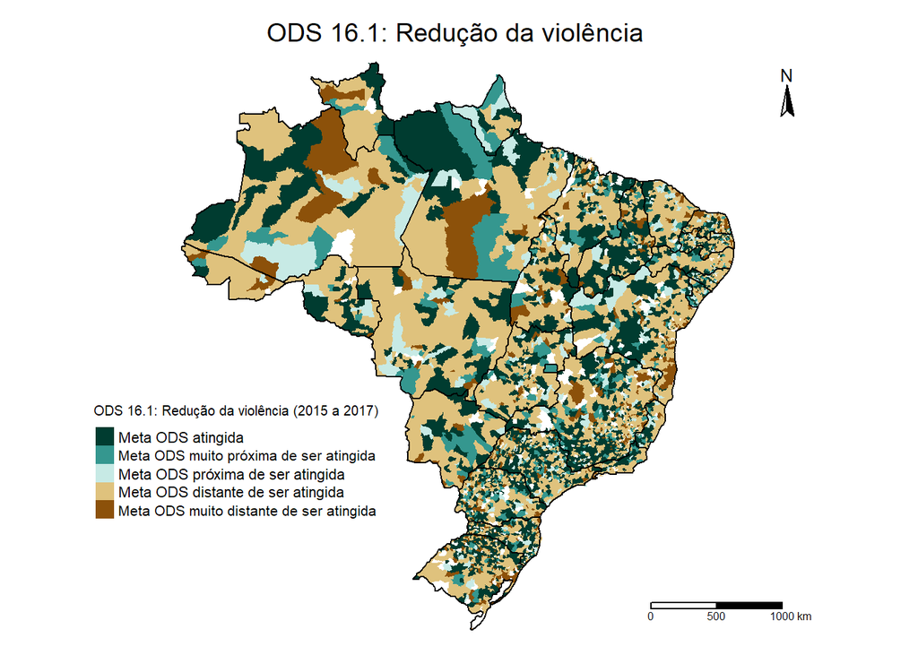

#### Resumo por biomas

ODS Meta 16.1: Redução da violência (2015 a 2017)

| Bioma | Nº total de municípios | Meta ODS atingida Nº de municípios | Meta ODS atingida % no bioma | Municípios próximos de atingir a meta ODS Muito próximos Nº de municípios | Municípios próximos de atingir a meta ODS Muito próximos % no bioma | Municípios próximos de atingir a meta ODS Próximos Nº de municípios | Municípios próximos de atingir a meta ODS Próximos % no bioma | Municípios distantes de atingir a meta ODS Distantes Nº de municípios | Municípios distantes de atingir a meta ODS Distantes % no bioma | Municípios distantes de atingir a meta ODS Muito distantes Nº de municípios | Municípios distantes de atingir a meta ODS Muito distantes % no bioma |
| --- | --- | --- | --- | --- | --- | --- | --- | --- | --- | --- | --- |
| Amazonia | 553 | 175 | 31.6% | 35 | 6.3% | 46 | 8.3% | 267 | 48.3% | 30 | 5.4% |
| Caatinga | 1217 | 468 | 38.5% | 85 | 7.0% | 83 | 6.8% | 496 | 40.8% | 85 | 7.0% |
| Cerrado | 806 | 323 | 40.1% | 65 | 8.1% | 59 | 7.3% | 307 | 38.1% | 52 | 6.5% |
| Mata Atlântica | 2875 | 1272 | 44.2% | 148 | 5.1% | 141 | 4.9% | 1062 | 36.9% | 252 | 8.8% |
| Pampa | 94 | 25 | 26.6% | 3 | 3.2% | 2 | 2.1% | 39 | 41.5% | 25 | 26.6% |
| Pantanal | 19 | 6 | 31.6% | 1 | 5.3% | 2 | 10.5% | 10 | 52.6% | Não há | Não há |

#### Resumo por tipologias

ODS Meta 16.1: Redução da violência (2015 a 2017)

| Tipologia | Nº total de municípios | Meta ODS atingida Nº de municípios | Meta ODS atingida % no bioma | Municípios próximos de atingir a meta ODS Muito próximos Nº de municípios | Municípios próximos de atingir a meta ODS Muito próximos % no bioma | Municípios próximos de atingir a meta ODS Próximos Nº de municípios | Municípios próximos de atingir a meta ODS Próximos % no bioma | Municípios distantes de atingir a meta ODS Distantes Nº de municípios | Municípios distantes de atingir a meta ODS Distantes % no bioma | Municípios distantes de atingir a meta ODS Muito distantes Nº de municípios | Municípios distantes de atingir a meta ODS Muito distantes % no bioma |
| --- | --- | --- | --- | --- | --- | --- | --- | --- | --- | --- | --- |
| Intermediário | 891 | 208 | 23.3% | 72 | 8.1% | 66 | 7.4% | 472 | 53.0% | 73 | 8.2% |
| Rural | 4363 | 2034 | 46.6% | 244 | 5.6% | 246 | 5.6% | 1495 | 34.3% | 344 | 7.9% |
| Urbano | 310 | 27 | 8.7% | 21 | 6.8% | 21 | 6.8% | 214 | 69.0% | 27 | 8.7% |

## Critérios únicos (IBGE/IPEA) - Mulheres

**Cortes**

- Meta ODS atingida: Decrescimento de ao menos 33% na taxa de mortalidade por homicídio intencional de 2015 para 2017 ou taxa zerada em 2017.
- Meta ODS muito próxima de ser atingida: Evolução da taxa de -32.53% a -17.62%.
- Meta ODS próxima de ser atingida: Evolução da taxa de -17.62% a 0%.
- Meta ODS distante de ser atingida: Evolução da taxa de 0% a 946.73%.
- Meta ODS muito distante de ser atingida: Evolução da taxa de 946.73% a 7809.11%.

**Resumo por região**

ODS Meta 16.1: Redução da violência - Homicídios de mulheres (2015 a 2017)

| REGIAO | Meta ODS atingida | Municípios próximos de atingir a meta ODS Meta ODS muito próxima de ser atingida | Municípios próximos de atingir a meta ODS Meta ODS próxima de ser atingida | Municípios distantes de atingir a meta ODS Meta ODS distante de ser atingida | Municípios distantes de atingir a meta ODS Meta ODS muito distante de ser atingida |
| --- | --- | --- | --- | --- | --- |
| Centro-Oeste | 69,96% | 1,93% | 1,50% | 26,18% | 0,43% |
| Nordeste | 66,98% | 0,73% | 0,73% | 30,17% | 1,39% |
| Norte | 64,59% | 1,78% | 1,34% | 31,85% | 0,45% |
| Sudeste | 74,58% | 1,20% | 1,50% | 19,66% | 3,06% |
| Sul | 79,461% | 1,010% | 0,926% | 16,077% | 2,525% |

**Distribuição espacial**

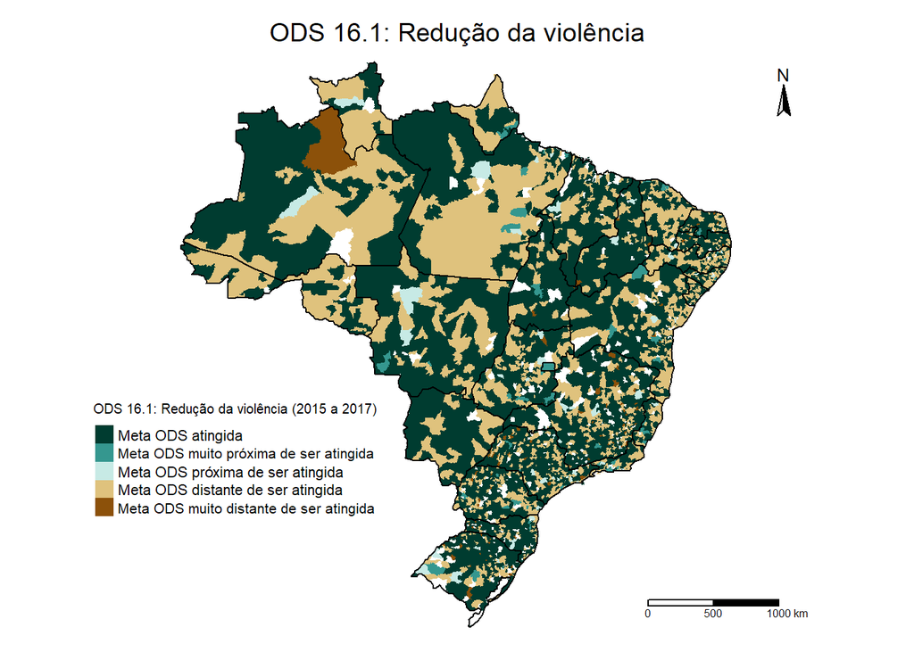

#### Resumo por biomas

ODS Meta 16.1: Redução da violência (2015 a 2017)

| Bioma | Nº total de municípios | Meta ODS atingida Nº de municípios | Meta ODS atingida % no bioma | Municípios próximos de atingir a meta ODS Muito próximos Nº de municípios | Municípios próximos de atingir a meta ODS Muito próximos % no bioma | Municípios próximos de atingir a meta ODS Próximos Nº de municípios | Municípios próximos de atingir a meta ODS Próximos % no bioma | Municípios distantes de atingir a meta ODS Distantes Nº de municípios | Municípios distantes de atingir a meta ODS Distantes % no bioma | Municípios distantes de atingir a meta ODS Muito distantes Nº de municípios | Municípios distantes de atingir a meta ODS Muito distantes % no bioma |
| --- | --- | --- | --- | --- | --- | --- | --- | --- | --- | --- | --- |
| Amazonia | 553 | 350 | 63.3% | 7 | 1.3% | 10 | 1.8% | 185 | 33.5% | 1 | 0.2% |
| Caatinga | 1217 | 843 | 69.3% | 9 | 0.7% | 8 | 0.7% | 334 | 27.4% | 23 | 1.9% |
| Cerrado | 806 | 615 | 76.3% | 7 | 0.9% | 9 | 1.1% | 168 | 20.8% | 7 | 0.9% |
| Mata Atlântica | 2875 | 2123 | 73.8% | 36 | 1.3% | 32 | 1.1% | 608 | 21.1% | 76 | 2.6% |
| Pampa | 94 | 61 | 64.9% | 2 | 2.1% | 3 | 3.2% | 25 | 26.6% | 3 | 3.2% |
| Pantanal | 19 | 13 | 68.4% | 1 | 5.3% | Não há | Não há | 5 | 26.3% | Não há | Não há |

#### Resumo por tipologias

ODS Meta 16.1: Redução da violência (2015 a 2017)

| Tipologia | Nº total de municípios | Meta ODS atingida Nº de municípios | Meta ODS atingida % no bioma | Municípios próximos de atingir a meta ODS Muito próximos Nº de municípios | Municípios próximos de atingir a meta ODS Muito próximos % no bioma | Municípios próximos de atingir a meta ODS Próximos Nº de municípios | Municípios próximos de atingir a meta ODS Próximos % no bioma | Municípios distantes de atingir a meta ODS Distantes Nº de municípios | Municípios distantes de atingir a meta ODS Distantes % no bioma | Municípios distantes de atingir a meta ODS Muito distantes Nº de municípios | Municípios distantes de atingir a meta ODS Muito distantes % no bioma |
| --- | --- | --- | --- | --- | --- | --- | --- | --- | --- | --- | --- |
| Intermediário | 891 | 466 | 52.3% | 27 | 3.0% | 25 | 2.8% | 369 | 41.4% | 4 | 0.4% |
| Rural | 4363 | 3454 | 79.2% | 8 | 0.2% | 12 | 0.3% | 783 | 17.9% | 106 | 2.4% |
| Urbano | 310 | 85 | 27.4% | 27 | 8.7% | 25 | 8.1% | 173 | 55.8% | Não há | Não há |

## Critérios únicos (IBGE/IPEA) - Pretos e pardos

**Cortes**

- Meta ODS atingida: Decrescimento de ao menos 33% na taxa de mortalidade por homicídio intencional de 2015 para 2017 ou taxa zerada em 2017.
- Meta ODS muito próxima de ser atingida: Evolução da taxa de -32.9% a -16.13%.
- Meta ODS próxima de ser atingida: Evolução da taxa de -16.13% a 0%.
- Meta ODS distante de ser atingida: Evolução da taxa de 0% a 543.45%.
- Meta ODS muito distante de ser atingida: Evolução da taxa de 543.45% a 6310.37%.

**Resumo por região**

ODS Meta 16.1: Redução da violência - Homicídios de pessoas negras (2015 a 2017)

| REGIAO | Meta ODS atingida | Municípios próximos de atingir a meta ODS Meta ODS muito próxima de ser atingida | Municípios próximos de atingir a meta ODS Meta ODS próxima de ser atingida | Municípios distantes de atingir a meta ODS Meta ODS distante de ser atingida | Municípios distantes de atingir a meta ODS Meta ODS muito distante de ser atingida |
| --- | --- | --- | --- | --- | --- |
| Centro-Oeste | 40,3% | 8,6% | 3,4% | 47,4% | 0,2% |
| Nordeste | 34,4% | 5,4% | 7,3% | 52,7% | 0,3% |
| Norte | 35,86% | 4,45% | 5,35% | 54,12% | 0,22% |
| Sudeste | 55,76% | 3,36% | 4,08% | 35,19% | 1,62% |
| Sul | 72,39% | 1,60% | 1,01% | 20,03% | 4,97% |

**Distribuição espacial**

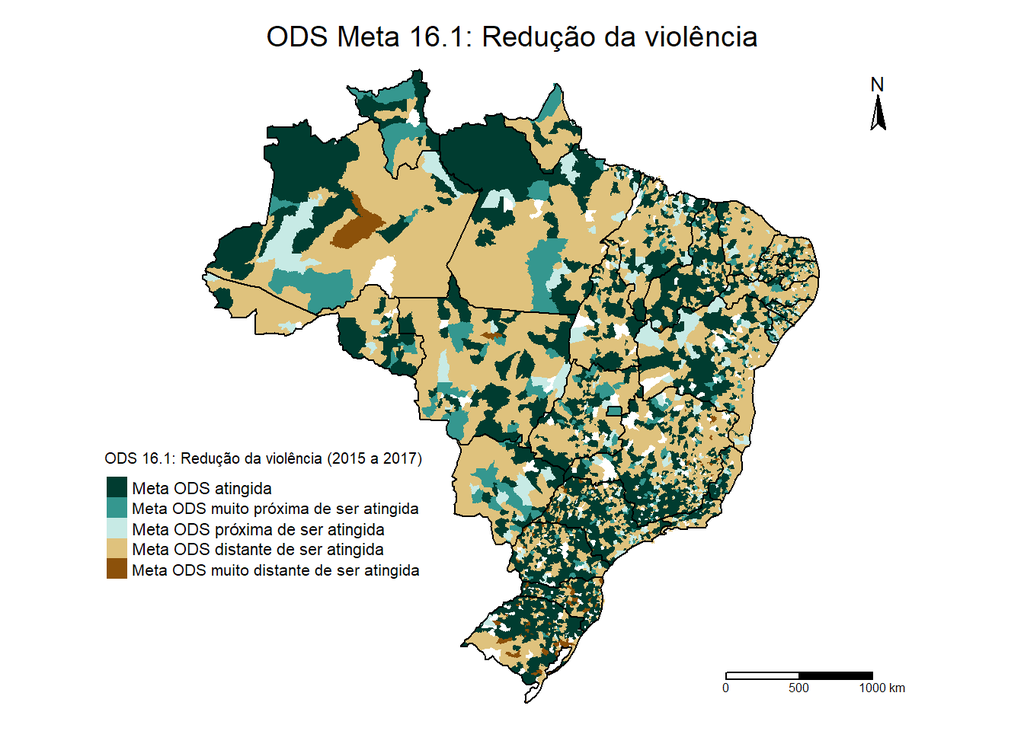

#### Resumo por biomas

ODS Meta 16.1: Redução da violência (2015 a 2017)

| Bioma | Nº total de municípios | Meta ODS atingida Nº de municípios | Meta ODS atingida % no bioma | Municípios próximos de atingir a meta ODS Muito próximos Nº de municípios | Municípios próximos de atingir a meta ODS Muito próximos % no bioma | Municípios próximos de atingir a meta ODS Próximos Nº de municípios | Municípios próximos de atingir a meta ODS Próximos % no bioma | Municípios distantes de atingir a meta ODS Distantes Nº de municípios | Municípios distantes de atingir a meta ODS Distantes % no bioma | Municípios distantes de atingir a meta ODS Muito distantes Nº de municípios | Municípios distantes de atingir a meta ODS Muito distantes % no bioma |
| --- | --- | --- | --- | --- | --- | --- | --- | --- | --- | --- | --- |
| Amazonia | 553 | 188 | 34.0% | 35 | 6.3% | 29 | 5.2% | 299 | 54.1% | 2 | 0.4% |
| Caatinga | 1217 | 465 | 38.2% | 71 | 5.8% | 79 | 6.5% | 595 | 48.9% | 7 | 0.6% |
| Cerrado | 806 | 388 | 48.1% | 43 | 5.3% | 44 | 5.5% | 330 | 40.9% | 1 | 0.1% |
| Mata Atlântica | 2875 | 1662 | 57.8% | 80 | 2.8% | 96 | 3.3% | 971 | 33.8% | 66 | 2.3% |
| Pampa | 94 | 49 | 52.1% | Não há | Não há | 1 | 1.1% | 26 | 27.7% | 18 | 19.1% |
| Pantanal | 19 | 3 | 15.8% | 2 | 10.5% | 1 | 5.3% | 13 | 68.4% | Não há | Não há |

#### Resumo por tipologias

ODS Meta 16.1: Redução da violência (2015 a 2017)

| Tipologia | Nº total de municípios | Meta ODS atingida Nº de municípios | Meta ODS atingida % no bioma | Municípios próximos de atingir a meta ODS Muito próximos Nº de municípios | Municípios próximos de atingir a meta ODS Muito próximos % no bioma | Municípios próximos de atingir a meta ODS Próximos Nº de municípios | Municípios próximos de atingir a meta ODS Próximos % no bioma | Municípios distantes de atingir a meta ODS Distantes Nº de municípios | Municípios distantes de atingir a meta ODS Distantes % no bioma | Municípios distantes de atingir a meta ODS Muito distantes Nº de municípios | Municípios distantes de atingir a meta ODS Muito distantes % no bioma |
| --- | --- | --- | --- | --- | --- | --- | --- | --- | --- | --- | --- |
| Intermediário | 891 | 262 | 29.4% | 48 | 5.4% | 57 | 6.4% | 515 | 57.8% | 9 | 1.0% |
| Rural | 4363 | 2458 | 56.3% | 165 | 3.8% | 172 | 3.9% | 1487 | 34.1% | 81 | 1.9% |
| Urbano | 310 | 35 | 11.3% | 18 | 5.8% | 21 | 6.8% | 232 | 74.8% | 4 | 1.3% |